*Search and replace a new line character in Atom:* `\r?\n|\r` --> ''  
https://stackoverflow.com/questions/31400866/how-do-i-replace-a-newline-in-atom

# Table of Contents

- imports

  > Imports
- numpy

  > numpy.in1d | numpy.intersect1d | numpy.setdiff1d | numpy.concatenate  
  > numpy array types  
  > numpy - ravel(), flatten(), and squeeze() Random numbers in Python np.nansum  
  > random.shuffle, random.random, random.choice, random.choices  
  > [np.count_nonzero(~np.isnan(a))](https://numpy.org/doc/stable/reference/generated/numpy.count_nonzero.html)  
  > [numpy.where](https://numpy.org/doc/stable/reference/generated/numpy.where.html)  
  > [numpy.allclose](https://numpy.org/doc/stable/reference/generated/numpy.allclose.html)
- scipy

  > scipy.special.binom
- pandas

  > pandas.Series str.replace, str.split, str.get, str.contains, str.slice, etc  
  > pandas.Series.apply  
  > pandas.DataFrame.any  
  > pandas.DataFrame to_csv, to_json, etc  
  > [DataFrame.select_dtypes](https://pandas.pydata.org/docs/reference/api/pandas.DataFrame.select_dtypes.html)  
  > [pandas.get_dummies](https://pandas.pydata.org/pandas-docs/version/0.17.0/generated/pandas.get_dummies.html)  
  > Pandas date_range  
  > [Reshaping and pivot tables](https://pandas.pydata.org/docs/user_guide/reshaping.html) | [memory error w/ pivot_table](https://stackoverflow.com/questions/39648991/pandas-dataframe-pivot-not-fitting-in-memory)  
  > [pandas dataframe query function](https://pandas.pydata.org/docs/reference/api/pandas.DataFrame.query.html)
- python

  > any and all functions  
  > continue and break  
  > iter (create an iterator object)  
  > tqdm.tqdm (extensible progress bar)  
  > timeit  
  > raw strings  
  > for-else  
  > time.perf_counter, time.time  
  > naming with underscores  
  > yield (prime numbers!)  
  > floor() and int()  
  > Hadamard product (of matrices)  
  > string.punctuation  
  > Enumerate  
  > regex  
  > csv read and write  
  > Pickle & JSON file formats  
  > Counting words  
  > String punctuations
- dictionaries

  > Sort a dictionary  
  > Dict vs Defaultdict  
  > Get() method for dictionaries
- sets

  > The empty set  
  > Set operations
- Classes

  > Decorator  
  > The super() class  
  > Class and Instance Attributes  
  > Class methods, static methods, and regular instance methods  
  > Abstract Classes in Python
- scikit-learn

  > sklearn.feature_extraction.text.CountVectorizer  
  > sklearn.feature_extraction.text.TfidfVectorizer
- nltk

  > NLTK  
  > Bag of words
- SQL

  > SQLite, SQLAlchemy
- General

  > Ordinary Least Squares  
  > echo http proxy  
  > CI/CD  
  > Scratch work  
  > End of Page

## Imports

```python
import os
import json
import re, string, timeit
import time
import math
import scipy.special as ss
import numpy as np
import pandas as pd
import requests
import matplotlib.pyplot as plt; plt.style.use('ggplot')

import statsmodels.api as sm

from numpy import log as ln
from time import perf_counter
from datetime import datetime, date, timedelta
from string import punctuation

from collections import defaultdict, Counter
from matplotlib.colors import ListedColormap
from nltk.tokenize import word_tokenize, sent_tokenize, RegexpTokenizer
from nltk.stem import WordNetLemmatizer, SnowballStemmer
from sklearn.feature_extraction.text import CountVectorizer,TfidfVectorizer

%matplotlib inline
%config InlineBackend.figure_format='retina'

plt.rcParams['figure.figsize']=[12, 8]
```

```
from IPython.display import Latex, display, HTML

#display(HTML(df.to_html(index=False)))

#display(Latex(r"""\begin{equation*}...\end{equation*}"""))
```

back to top

## Counting words

```python
"""Count words."""

def count_words(text):
    """Count how many times each unique word occurs in text."""
    counts = dict()  # dictionary of { <word>: <count> } pairs to return

    # TODO: Convert to lowercase
    text = text.lower()
    # TODO: Split text into tokens (words), leaving out punctuation
    # (Hint: Use regex to split on non-alphanumeric characters)
    text_list = re.split('[^a-zA-Z0-9]', text.lower())
    non_empty_indx = np.in1d(text_list, [''], invert=True)
    text_list = np.asarray(text_list)[non_empty_indx].tolist()
    text_set = set(text_list)
    # TODO: Aggregate word counts using a dictionary
    for word in text_set:
        counts[word] = sum(np.in1d(text_list, [word]))

    return counts


def test_run():
    with open("input.txt", "r") as f:
        text = f.read()
        counts = count_words(text)
        sorted_counts = sorted(counts.items(), key=lambda pair: pair[1], reverse=True)

        print("10 most common words:\nWord\tCount")
        for word, count in sorted_counts[:10]:
            print("{}\t{}".format(word, count))

        print("\n10 least common words:\nWord\tCount")
        for word, count in sorted_counts[-10:]:
            print("{}\t{}".format(word, count))


if __name__ == "__main__":
    test_run()
```

```
10 most common words:
Word	Count
a	9
he	6
the	6
and	5
was	4
as	4
with	3
i	2
his	2
left	2

10 least common words:
Word	Count
favoured	1
hip	1
whistling	1
plain	1
smiling	1
tables	1
long	1
it	1
managed	1
but	1
```

```python
with open('input.txt', 'r') as f:
    text = f.read()
```

```python
text = re.split('[^a-zA-Z0-9]', text.lower())
indexes = np.in1d(text,[''], invert=True)

indexes
```

```
array([ True,  True,  True,  True, False,  True,  True,  True,  True,
        True,  True,  True,  True, False,  True,  True,  True,  True,
        True,  True,  True,  True,  True,  True,  True,  True, False,
        True,  True,  True,  True,  True,  True,  True,  True,  True,
        True, False,  True,  True,  True,  True,  True,  True,  True,
        True,  True, False,  True,  True,  True,  True,  True,  True,
       False,  True,  True,  True,  True,  True,  True,  True, False,
        True,  True,  True,  True,  True,  True, False,  True,  True,
        True,  True,  True,  True,  True,  True, False, False,  True,
        True,  True, False,  True,  True,  True,  True, False,  True,
       False,  True,  True,  True,  True,  True,  True,  True, False,
        True,  True,  True,  True,  True,  True,  True,  True, False,
        True,  True,  True,  True,  True,  True,  True,  True,  True,
        True,  True,  True,  True,  True,  True,  True,  True, False,
       False])
```

back to top

## String punctuations

```python
'[%s]' % re.escape(string.punctuation)
```

```
'[!"\\#\\$%\\&\'\\(\\)\\*\\+,\\-\\./:;<=>\\?@\\[\\\\\\]\\^_`\\{\\|\\}\\~]'
```

```python
def remove_punctuation(st):
    st = re.sub(u"\â€”", " ", st)
    #st = re.sub(u"\u2014", "-", st)
    regex = re.compile('[%s]' % re.escape(string.punctuation))
    return regex.sub('', st)
```

```python
text = re.sub(r'[^\w\s]','',text)

text
```

```
'As I was waiting a man came out of a side room and at a glance I was sure he must be Long John His left leg was cut off close by the hip and under the left shoulder he carried a crutch which he managed with wonderful dexterity hopping about upon it like a bird He was very tall and strong with a fac…
```

```python
re.escape(string.punctuation)
```

```
'!"\\#\\$%\\&\'\\(\\)\\*\\+,\\-\\./:;<=>\\?@\\[\\\\\\]\\^_`\\{\\|\\}\\~'
```

```python
string.punctuation
```

```
'!"#$%&\'()*+,-./:;<=>?@[\\]^_`{|}~'
```

```python
import re, string, timeit

s = "string. With. Punctuation"
exclude = set(string.punctuation)
table = str.maketrans("","", string.punctuation)
regex = re.compile('[%s]' % re.escape(string.punctuation))

def test_set(s):
    return ''.join(c for c in s if c not in exclude)

def test_re(s):  # From Vinko's solution, with fix.
    return regex.sub('', s)

def test_trans(s):
    return s.translate(table)

def test_repl(s):  # From S.Lott's solution
    for c in string.punctuation:
        s=s.replace(c,"")
    return s

print(f"sets      : %s" % timeit.Timer('f(s)', 'from __main__ import s,test_set as f').timeit(1000000))
print(f"regex     : %s" % timeit.Timer('f(s)', 'from __main__ import s,test_re as f').timeit(1000000))
print(f"translate : %s" % timeit.Timer('f(s)', 'from __main__ import s,test_trans as f').timeit(1000000))
print(f"replace   : %s" % timeit.Timer('f(s)', 'from __main__ import s,test_repl as f').timeit(1000000))
```

```
sets      : 2.9976677999998174
regex     : 1.1377211000003626
translate : 1.3546903999999813
replace   : 4.9771482999999535
```

```python
import re
s = "string. With. Punctuation?"
s = re.sub(r'[^\w\s]','',s)
```

```python
s
```

```
'string With Punctuation'
```

```python
inner_tab = "12345"
outter_tab = "aeiou"
trans_tab = str.maketrans(inner_tab, outter_tab)

s = "th3s 3s str3ng 2x1mpl2....w4w!!!";
print (s.translate(trans_tab))
```

```
this is string example....wow!!!
```

```python
set(string.punctuation)
```

```
{'!',
 '"',
 '#',
 '$',
 '%',
 '&',
 "'",
 '(',
 ')',
 '*',
 '+',
 ',',
 '-',
 '.',
 '/',
 ':',
 ';',
 '<',
 '=',
 '>',
 '?',
 '@',
 '[',
 '\\',
 ']',
 '^',
 '_',
 '`',
 '{',
 '|',
 '}',
 '~'}
```

back to top

## NLTK (Natural Language Tool Kit)

[nltk.tokenize](https://www.nltk.org/api/nltk.tokenize.html)

```python
from nltk.tokenize import word_tokenize, sent_tokenize
```

```python
# words = word_tokenize(text)
```

```python
# sentences = sent_tokenize(text)
```

back to top

## `numpy.in1d`

```python
import numpy as np

np.in1d([1,2,3,4], [1,3,5])
```

```
array([ True, False,  True, False])
```

```python
np.in1d([1,3,5],[1,2,3,4])
```

```
array([ True,  True, False])
```

# numpy.intersect1d

```python
np.intersect1d([1,2,3,4], [1,3,5])
```

```
array([1, 3])
```

```python
np.intersect1d([1,2,3,4,3,6], [1,3,5], assume_unique=True)
```

```
array([1, 3, 3])
```

```python
np.intersect1d([1,3,5], [1,2,3,4,3,6], assume_unique=True)
```

```
array([1, 3, 3])
```

```python
np.intersect1d([1,3,5], [1,2,3,4,3,6])
```

```
array([1, 3])
```

# numpy.setdiff1d

```python
a = np.array([1, 2, 3, 2, 4, 1])
b = np.array([3, 4, 5, 6])
np.setdiff1d(a, b)
```

```
array([1, 2])
```

```python
np.setdiff1d(b, a)
```

```
array([5, 6])
```

# numpy.concatenate

```python
a = np.array([[1, 2], [3, 4]])
b = np.array([[5, 6]])
np.concatenate((a, b), axis=0)
```

```
array([[1, 2],
       [3, 4],
       [5, 6]])
```

```python
np.concatenate((a, b.T), axis=1)
```

```
array([[1, 2, 5],
       [3, 4, 6]])
```

```python
np.concatenate((a, b), axis=None)
```

```
array([1, 2, 3, 4, 5, 6])
```

back to top

## `os.path.isfile`

```python
import os

os.path.isfile('inputs.txt')
```

```
False
```

```python
os.path.isfile('input.txt')
```

```
True
```

back to top

## `any()` and `all()`

```python
lst1, lst2 = 'a b c d e f'.split(), 'b c f g h'.split()

lst1, lst2
```

```
(['a', 'b', 'c', 'd', 'e', 'f'], ['b', 'c', 'f', 'g', 'h'])
```

```python
[w in lst1 for w in lst2] #[True, True, True, False, False]
```

```
[True, True, True, False, False]
```

```python
[w in lst2 for w in lst1] # [False, True, True, False, False, True]
```

```
[False, True, True, False, False, True]
```

```python
any([w in lst2 for w in lst1])
```

```
True
```

```python
all([w in lst2 for w in lst1])
```

```
False
```

back to top

## Sort a dictionary by values and print

```python
# useful function to print a dictionary sorted by value (largest first by default)
def print_sorted(d, ascending=False):
    factor = 1 if ascending else -1
    sorted_list = sorted(d.items(), key=lambda v: factor*v[1])
    for i, v in sorted_list:
        print("{}: {:.3f}".format(i, v))
```

```python
d = {'jan': 18.78, 'feb': 15.97, 'mar': 20.73, 'apr': 19.99, 'may': 15.01, 'jun': 24.02}
print_sorted(d)
```

```
jun: 24.020
mar: 20.730
apr: 19.990
jan: 18.780
feb: 15.970
may: 15.010
```

```python
max(d, key=d.get)
```

```
'jun'
```

```python
min(d, key=d.get)
```

```
'may'
```

```python
# useful function to print a dictionary sorted by value (largest first by default)
def print_sorted_2(d, ascending=False):
    sort_key = lambda dic_items: dic_items[1]
    sorted_list = sorted(d.items(), key=sort_key, reverse=ascending)
    for i, v in sorted_list:
        print("{}: {:.3f}".format(i, v))
```

```python
print_sorted_2(d)
```

```
may: 15.010
feb: 15.970
jan: 18.780
apr: 19.990
mar: 20.730
jun: 24.020
```

```python
print_sorted_2(d, True)
```

```
jun: 24.020
mar: 20.730
apr: 19.990
jan: 18.780
feb: 15.970
may: 15.010
```

back to top

## Get() method for dictionaries

In Python dictionaries, the following is aconventional method to access a value for a key

```python
dic = {'A': 1, 'B':2}
print(dic['A'])
print(dic['C'])
```

```
1
```

```
---------------------------------------------------------------------------
KeyError                                  Traceback (most recent call last)
<ipython-input-1-924c654ba480> in <module>
      1 dic = {'A': 1, 'B':2}
      2 print(dic['A'])
----> 3 print(dic['C'])

KeyError: 'C'
```

The `get()` method is used to avoid a situation like the above where **KeyError** is raised. This method returns the value for the given key, if present in the dictionary. If not, it will return None (if get is used with only one argument).

**Syntax:**

`Dict.get(key, defual=None)`

```python
print(dic.get('A'))
print(dic.get('B'))
print(dic.get('C'))
print(dic.get('C', 'Not found !'))
```

```
1
2
None
Not found !
```

back to top

## Dict vs Defaultdict

[defaultdict (GeeksforGeeks)](https://www.geeksforgeeks.org/defaultdict-in-python/)

**Defaultdict** is a container like dictionaries present in the module collections. Defaultdict is a sub-class of the `dict` class that returns a dictionary-like object. The functionality of both dictionaries and defualtdict are almost same except for the fact that `defualtdict` never raises a `KeyError`. It provides a default value for the key that does not exists.

```python
import numpy as np
from collections import defaultdict
from nltk.tokenize import RegexpTokenizer

word_tokenizer = RegexpTokenizer(r'[^\d\W]+')
```

```python
txt = 'Defaultdict is a container like dictionaries present in the module collections. \
Defaultdict is a sub-class of the dict class that returns a dictionary-like object. \
The functionality of both dictionaries and defualtdict are almost same except for the \
fact that defualtdict never raises a KeyError. It provides a default value for the key \
that does not exists.'
```

```python
words = list(map(str.lower, word_tokenizer.tokenize(txt)))
distinct_words = set(words)
```

```python
term_frequency = defaultdict(int)

for word in distinct_words:
    term_frequency[word] = sum(np.in1d(words, [word]))

print_sorted(term_frequency)
```

```
the: 5.000
a: 5.000
that: 3.000
for: 2.000
defualtdict: 2.000
of: 2.000
is: 2.000
defaultdict: 2.000
dictionaries: 2.000
class: 2.000
like: 2.000
exists: 1.000
in: 1.000
object: 1.000
collections: 1.000
does: 1.000
dict: 1.000
not: 1.000
default: 1.000
container: 1.000
same: 1.000
except: 1.000
functionality: 1.000
key: 1.000
returns: 1.000
are: 1.000
value: 1.000
fact: 1.000
sub: 1.000
raises: 1.000
present: 1.000
never: 1.000
dictionary: 1.000
and: 1.000
it: 1.000
provides: 1.000
almost: 1.000
both: 1.000
module: 1.000
keyerror: 1.000
```

```python
'hailu' in words
```

```
False
```

```python
# A defaultdict never raises a KeyError
term_frequency['hailu']
```

```
0
```

```python
term_frequency.values()
```

```
dict_values([3, 1, 1, 1, 5, 1, 2, 1, 2, 1, 1, 1, 1, 1, 1, 1, 1, 1, 1, 1, 1, 2, 2, 2, 2, 1, 1, 1, 2, 1, 2, 1, 1, 5, 1, 1, 1, 1, 1, 1, 0])
```

```python
term_frequency.keys()
```

```
dict_keys(['that', 'exists', 'in', 'object', 'the', 'collections', 'for', 'does', 'defualtdict', 'dict', 'not', 'default', 'container', 'same', 'except', 'functionality', 'key', 'returns', 'are', 'value', 'fact', 'of', 'is', 'defaultdict', 'dictionaries', 'sub', 'raises', 'present', 'class', 'never'…
```

back to top

## Bag of words

```python
from collections import defaultdict
```

```python
def bag_of_words(words):
    bag = defaultdict(int)
    for w in words:
        bag[w] += 1
    return bag
```

```python
def bag_of_words_2(words):
    # TO DO
    d = {}
    distinct_words = set(words)
    for word in distinct_words:
        d[word] = np.sum(np.in1d(words, [word]))

    return d
```

```python
from nltk.tokenize import RegexpTokenizer

word_tokenizer = RegexpTokenizer(r'[^\d\W]+')
```

```python
txt = 'Limited time offer. You will be charged the introductory rate of $4 every four weeks for \
the introductory period of one year, and thereafter will be charged the standard rate of $17 every \
four weeks until you cancel. All subscriptions renew automatically. You can cancel anytime. \
A cancellation will be effective at the end of the then-current billing cycle. Mobile apps are \
not supported on all devices. These offers are not available for current subscribers. Other \
restrictions and taxes may apply. Offers and pricing are subject to change without notice.'
```

```python
word_tokenizer.tokenize(txt)
```

```
['Limited',
 'time',
 'offer',
 'You',
 'will',
 'be',
 'charged',
 'the',
 'introductory',
 'rate',
 'of',
 'every',
 'four',
 'weeks',
 'for',
 'the',
 'introductory',
 'period',
 'of',
 'one',
 'year',
 'and',
 'thereafter',
 'will',
 'be',
 'charged',
 'the',
 'standard',
 'rate',
 'of',
 'every',
 'four',
 'weeks',
 'until',
 'you',
 'cancel',
 'All',
 'subscriptions',
 'renew',
 'automatically',
```

[output cut: 34 more lines]

```
 'Other',
 'restrictions',
 'and',
 'taxes',
 'may',
 'apply',
 'Offers',
 'and',
 'pricing',
 'are',
 'subject',
 'to',
 'change',
 'without',
 'notice']
```

```python
from nltk.stem import WordNetLemmatizer, SnowballStemmer

wnl = WordNetLemmatizer()
sno = SnowballStemmer('english')
```

```python
lemm_words = [wnl.lemmatize(wnl.lemmatize(word.lower(), 'n'), 'v')
        for word in word_tokenizer.tokenize(txt) if word.isalpha()]
```

```python
words = [sno.stem(word) for word in lemm_words]
```

```python
print_sorted(bag_of_words(words))
```

```
be: 6.000
the: 5.000
of: 4.000
offer: 3.000
you: 3.000
will: 3.000
and: 3.000
cancel: 3.000
charg: 2.000
introductori: 2.000
rate: 2.000
everi: 2.000
four: 2.000
week: 2.000
for: 2.000
all: 2.000
current: 2.000
not: 2.000
limit: 1.000
time: 1.000
period: 1.000
one: 1.000
year: 1.000
thereaft: 1.000
standard: 1.000
until: 1.000
subscript: 1.000
renew: 1.000
automat: 1.000
can: 1.000
anytim: 1.000
a: 1.000
effect: 1.000
at: 1.000
end: 1.000
then: 1.000
bill: 1.000
cycl: 1.000
mobil: 1.000
app: 1.000
support: 1.000
on: 1.000
devic: 1.000
these: 1.000
avail: 1.000
subscrib: 1.000
other: 1.000
restrict: 1.000
tax: 1.000
may: 1.000
appli: 1.000
price: 1.000
subject: 1.000
to: 1.000
chang: 1.000
without: 1.000
notic: 1.000
```

```python
print_sorted(bag_of_words_2(words))
```

```
be: 6.000
the: 5.000
of: 4.000
will: 3.000
you: 3.000
offer: 3.000
cancel: 3.000
and: 3.000
for: 2.000
not: 2.000
current: 2.000
charg: 2.000
week: 2.000
four: 2.000
all: 2.000
rate: 2.000
everi: 2.000
introductori: 2.000
these: 1.000
avail: 1.000
limit: 1.000
may: 1.000
on: 1.000
chang: 1.000
time: 1.000
restrict: 1.000
to: 1.000
end: 1.000
appli: 1.000
at: 1.000
notic: 1.000
automat: 1.000
subject: 1.000
mobil: 1.000
one: 1.000
standard: 1.000
cycl: 1.000
subscript: 1.000
price: 1.000
app: 1.000
can: 1.000
period: 1.000
a: 1.000
other: 1.000
bill: 1.000
until: 1.000
renew: 1.000
thereaft: 1.000
year: 1.000
then: 1.000
tax: 1.000
effect: 1.000
subscrib: 1.000
anytim: 1.000
without: 1.000
support: 1.000
devic: 1.000
```

back to top

## sklearn.feature_extraction.text.CountVectorizer

https://scikit-learn.org/stable/modules/generated/sklearn.feature_extraction.text.CountVectorizer.html

```python
corpus = [
     'This is the first document.',
     'This document is the second document.',
     'And this is the third one.',
     'Is this the first document?',
 ]
```

```python
vectorizer = CountVectorizer()

X = vectorizer.fit_transform(corpus)

print(vectorizer.get_feature_names())
print()
print(X.toarray())
```

```
['and', 'document', 'first', 'is', 'one', 'second', 'the', 'third', 'this']

[[0 1 1 1 0 0 1 0 1]
 [0 2 0 1 0 1 1 0 1]
 [1 0 0 1 1 0 1 1 1]
 [0 1 1 1 0 0 1 0 1]]
```

```python
vectorizer2 = CountVectorizer(analyzer='word', ngram_range=(2, 2))

X2 = vectorizer2.fit_transform(corpus)

print(vectorizer2.get_feature_names())
```

```
['and this', 'document is', 'first document', 'is the', 'is this', 'second document', 'the first', 'the second', 'the third', 'third one', 'this document', 'this is', 'this the']
```

```python
print(X2.toarray())
```

```
[[0 0 1 1 0 0 1 0 0 0 0 1 0]
 [0 1 0 1 0 1 0 1 0 0 1 0 0]
 [1 0 0 1 0 0 0 0 1 1 0 1 0]
 [0 0 1 0 1 0 1 0 0 0 0 0 1]]
```

back to top

## sklearn.feature_extraction.text.TfidfVectorizer

https://scikit-learn.org/stable/modules/generated/sklearn.feature_extraction.text.TfidfVectorizer.html

Convert a collection of raw documents to a matrix of TF-IDF features.

Equivalent to CountVectorizer followed by TfidfTransformer.

```python
from sklearn.feature_extraction.text import TfidfVectorizer

corpus = [
    'This is the first document.',
    'This document is the second document.',
    'And this is the third one.',
    'Is this the first document?',
]

vectorizer = TfidfVectorizer()

X = vectorizer.fit_transform(corpus)

print(vectorizer.get_feature_names())
```

```
['and', 'document', 'first', 'is', 'one', 'second', 'the', 'third', 'this']
```

```python
print(X.shape)
```

```
(4, 9)
```

back to top

## Continue and break in python

[figure not shown]

back to top

## The empty set

```python
s,s1,s2,s3 = set(), {*()}, {*[]}, {*{}}

print(s)
print(s1)
print(s2)
print(s3)
```

```
set()
set()
set()
set()
```

```python
s.add('a')
```

```python
s
```

```
{'a'}
```

```python
s |= {'b', 'c', 'd'}

s
```

```
{'a', 'b', 'c', 'd'}
```

```python
s1 |= {1}
s1
```

```
{1}
```

back to top

## Set operations

```python
A, B = {0,2,4,6,8}, {1,2,3,4,5}
```

```python
A, B = {0,2,4,6,8}, {1,2,3,4,5}

# Sets A and B
print('A : ', A)
print('B : ', B)
print()

# Union
print('Union '+' '*14 +' : ', A | B)  # A.union(B)

# Intersection
print('Intersection '+' '*7 +' : ', A & B) # A.intersection(B)

# Difference
print('Difference, A - B '+' '*2 +' : ', A - B) # A.difference(B)

# Symmetric difference
print('Symmetric difference : ', A ^ B) # A.symmetric_difference(B)
```

```
A :  {0, 2, 4, 6, 8}
B :  {1, 2, 3, 4, 5}

Union                :  {0, 1, 2, 3, 4, 5, 6, 8}
Intersection         :  {2, 4}
Difference, A - B    :  {0, 8, 6}
Symmetric difference :  {0, 1, 3, 5, 6, 8}
```

```python
(22 - len('Union : ')),(20 - len('Intersection ')),(20 - len('Difference, A - B '))
```

```
(14, 7, 2)
```

```python
A.union(B)
```

```
{0, 1, 2, 3, 4, 5, 6, 8}
```

```python
A.intersection(B)
```

```
{2, 4}
```

```python
A.difference(B)
```

```
{0, 6, 8}
```

```python
A.symmetric_difference(B)
```

```
{0, 1, 3, 5, 6, 8}
```

## Dict of dicts

```python
d = {}
d['AAPL']=d['TSLA']=d['ZM'] = {}

d['AAPL']['2020-07-27'] = 380.98
d['TSLA']['2020-07-27'] = 1543.55
d['ZM']['2020-07-27'] = 252.76

d['AAPL']['2019-08-01'] = 209.68
d['TSLA']['2019-08-01'] = 242.26
d['ZM']['2019-08-01'] = 95.49
```

```python
d
```

```
{'AAPL': {'2020-07-27': 252.76, '2019-08-01': 95.49},
 'TSLA': {'2020-07-27': 252.76, '2019-08-01': 95.49},
 'ZM': {'2020-07-27': 252.76, '2019-08-01': 95.49}}
```

```python
d['AAPL'].values()
```

```
dict_values([252.76, 95.49])
```

```python
d.keys()
```

```
dict_keys(['AAPL', 'TSLA', 'ZM'])
```

```python
d.values()
```

```
dict_values([{'2020-07-27': 252.76, '2019-08-01': 95.49}, {'2020-07-27': 252.76, '2019-08-01': 95.49}, {'2020-07-27': 252.76, '2019-08-01': 95.49}])
```

back to top

## iter()

The `iter()` function creates an object which can be iterated one element at a time. These objects are useful when coupled with loops like `for loop` and `while loop`.

Syntax

`iter(object, sentinel)`

> - object - object whose iterator has to be created (can be sets, tuples, etc)
> - sentinel (optional) - special value that is used to represent the end of a sequence

```python
# list of vowels
vowels = 'a e i o u'.split()
vowels_iter = iter(vowels)

print(next(iter(vowels_iter)))  # 'a'
print(next(iter(vowels_iter)))  # 'e'
print(next(iter(vowels_iter)))  # 'i'
print(next(iter(vowels_iter)))  # 'o'
print(next(iter(vowels_iter)))  # 'u'
print(next(iter(vowels_iter)))  # StopIteration error
```

```
a
e
i
o
u
```

```
---------------------------------------------------------------------------
StopIteration                             Traceback (most recent call last)
<ipython-input-1-3d2c2483eb31> in <module>
      8 print(next(iter(vowels_iter)))  # 'o'
      9 print(next(iter(vowels_iter)))  # 'u'
---> 10 print(next(iter(vowels_iter)))  # StopIteration error

StopIteration:
```

```python
vowels
```

```
['a', 'e', 'i', 'o', 'u']
```

```python
vowels_iter = iter(vowels)
try:
    while True:
        print(next(vowels_iter))
except StopIteration:
    pass
finally:
    del vowels_iter
```

```
a
e
i
o
u
```

```python
! pip install tqdm
```

back to top

## tqdm

```python
import random
from tqdm.notebook import tqdm; getattr(tqdm, '_instances', {}).clear()
```

```python
a = [x for x in range(5000)]
random.shuffle(a)
print(a[:5], a[-5:])


for i in tqdm(range(len(a)), desc='Random Shuffle', unit=' Shuffle', ncols='75%'):
    for j in range(len(a)-i-1):
        if a[j] > a[j+1]:
            a[j],a[j+1] = a[j+1],a[j]

print(a[:5], a[-5:])
```

```
[405, 4103, 413, 3670, 4770] [907, 4765, 1490, 74, 2242]
```

```
[0, 1, 2, 3, 4] [4995, 4996, 4997, 4998, 4999]
```

```python
import string
from time import sleep
#from tqdm import tqdm

progress_bar = tqdm(list(string.ascii_lowercase))
for letter in progress_bar:
    progress_bar.set_description(f'Processing {letter}')
    sleep(0.1)
```

```python
for letter in tqdm(list(string.ascii_lowercase), desc=f'Processing {letter}', unit='char'):
    sleep(0.05)
```

back to top

# Binomial Coefficients

The [math](https://docs.python.org/3/library/math.html) package

```python
math.fsum([1, 2, 3, 4, 5, 6, 7, 8, 9])
```

```
45.0
```

```python
math.factorial(6)
```

```
720
```

```python
math.comb(6, 2)
```

```
15
```

```python
# import scipy.special as ss

ss.binom(6, 2)
```

```
15.0
```

```python
def binomial_distribution(n_trials, n_successes, p=0.5):
    return ss.binom(n_trials, n_successes) * math.pow(p, n_successes) * math.pow(1-p, n_trials - n_successes)
```

```python
start = perf_counter()
for k in range(7 + 1):
    print(f"{binomial_distribution(7, k, .2):.6f}", end=" ")

print(f"\nDuration: {perf_counter() - start} seconds")
```

```
0.209715 0.367002 0.275251 0.114688 0.028672 0.004301 0.000358 0.000013
Duration: 0.0004212000000052285 seconds
```

```python
np.sum([binomial_distribution(7, k, 0.2) for k in range(8)])
```

```
1.0000000000000004
```

back to top

# timeit

```python
import timeit
```

#### `timeit`: CLI

```python
! python -m timeit -s "l=[[1,2,3],[4,5,6],[7],[8,9]]*99" "[item for sublist in l for item in sublist]"
```

```
10000 loops, best of 5: 38.7 usec per loop
```

```python
! python -m timeit -s "l=[[1,2,3],[4,5,6], [7], [8,9]]*99" "sum(l, [])"
```

```
500 loops, best of 5: 531 usec per loop
```

```python
! python -m timeit -s "from functools import reduce" "l=[[1,2,3],[4,5,6],[7],[8,9]]*99" "reduce(lambda x,y:x+y,l)"
```

```
500 loops, best of 5: 524 usec per loop
```

```python
! python -m timeit -s "from functools import reduce" "l=[[1,2,3],[4,5,6],[7],[8,9]]*99" "reduce(lambda x,y:x+y,l)"
```

```
500 loops, best of 5: 516 usec per loop
```

#### `timeit`: Python Interface

```python
timeit.timeit('[item for sublist in [[1,2,3],[4,5,6],[7],[8,9]]*99 for item in sublist]',number=1000)
```

```
0.040909499999997934
```

```python
timeit.timeit('sum([[1,2,3],[4,5,6], [7], [8,9]]*99, [])', number=1000)
```

```
0.46729290000075707
```

```python
timeit.timeit("reduce(lambda x,y: x+y,[[1,2,3],[4,5,6],[7],[8,9]]*99)",
              "from functools import reduce", number=1000)
```

```
0.5066506000002846
```

back to top

## Raw strings

```python
print('Hello\n\tWorld')
```

```
Hello
	World
```

```python
print(r'Hello\n\tWorld')
```

```
Hello\n\tWorld
```

## pandas.Series str.* methods

[pandas.Series.str.+](https://pandas.pydata.org/pandas-docs/stable/reference/api/pandas.Series.str.replace.html)

## pandas.DataFrame.any

https://pandas.pydata.org/pandas-docs/stable/reference/api/pandas.DataFrame.any.html

```python
df = pd.DataFrame({"A": [1, 2], "B": [0, 2], "C": [0, 0]})

df
```

|  | A | B | C |
| --- | --- | --- | --- |
| 0 | 1 | 0 | 0 |
| 1 | 2 | 2 | 0 |

```python
df.any()
```

```
A     True
B     True
C    False
dtype: bool
```

```python
df.any(0)
```

```
A     True
B     True
C    False
dtype: bool
```

```python
df.any(axis='index')
```

```
A     True
B     True
C    False
dtype: bool
```

```python
df.any(1)
```

```
0    True
1    True
dtype: bool
```

```python
df.any(axis='columns')
```

```
0    True
1    True
dtype: bool
```

```python
df.any(axis=None)
```

```
True
```

```python
df.shape, len(df)
```

```
((2, 3), 2)
```

back to top

## pandas.Series.apply

[pd.Series.apply](https://pandas.pydata.org/pandas-docs/stable/reference/api/pandas.Series.apply.html)

```python
import numpy as np
import pandas as pd

s = pd.Series([20, 21, 12],
              index=['London', 'New York', 'Helsinki'])

s
```

```
London      20
New York    21
Helsinki    12
dtype: int64
```

```python
def square(x):
    return x**2

# a custom function that needs additional positional arguments
def subtract_custom_value(x, custom_value):
    return x - custom_value

# a custom function that takes keyword arguments
def add_custom_values(x, **kwargs):
    for month in kwargs:
        x += kwargs[month]
    return x
```

```python
s.apply(square)
```

```
London      400
New York    441
Helsinki    144
dtype: int64
```

```python
s.apply(lambda x: x**2)
```

```
London      400
New York    441
Helsinki    144
dtype: int64
```

```python
s.apply(subtract_custom_value, args=(5,))
```

```
London      15
New York    16
Helsinki     7
dtype: int64
```

```python
s.apply(add_custom_values, june=30, july=20, august=25)
```

```
London      95
New York    96
Helsinki    87
dtype: int64
```

```python
s.apply(np.log)
```

```
London      2.995732
New York    3.044522
Helsinki    2.484907
dtype: float64
```

back to top

## pandas.DataFrame to_csv, to_json, etc

[pd.dataframe to_csv/to_json/etc](https://pandas.pydata.org/pandas-docs/stable/reference/api/pandas.DataFrame.to_json.html)

back to top

## Numpy array types

Names for the data types that would clash with standard Python object names are followed by a trailing underscore, ’ ’. These data types are so named because they use the same underlying precision as the corresponding Python data types.

The array types `bool_`, `int_`, `complex_`, `float_`, `object_`, `unicode_`, and `str_` are enhanced-scalars. They are very similar to the standard Python types (without the trailing underscore) and inherit from them (except for `bool_` and `object_`). They can be used in place of the standard Python types whenever desired. Whenever a data type is required, as an argument, the standard Python types are recognized as well.

```python
import numpy as np
scalar = 3
L1 = [3]
L2 = [1, 2, 3]

np.float(scalar)  # okay
np.float(L1)  # breaks (TypeError)
np.float(L2)  # breaks (TypeError)

np.float_(scalar)  # okay
np.float_(L1)  # okay
np.float_(L2)  # okay
```

[output not shown]

back to top

```python
weights = np.random.normal(scale=1/np.sqrt(10), size=10)

np.zeros(weights.shape)
```

```
array([0., 0., 0., 0., 0., 0., 0., 0., 0., 0.])
```

## Numpy - `ravel()`, `flatten()`, and `squeeze()`

```python
import numpy as np

x_ = np.linspace(0., 1., 2)
y_ = np.linspace(1., 2., 3)
z_ = np.linspace(3., 4., 4)

x, y, z = np.meshgrid(x_, y_, z_, indexing='ij')

assert np.all(x[:,0,0] == x_)
assert np.all(y[0,:,0] == y_)
assert np.all(z[0,0,:] == z_)
```

```python
x
```

```
array([[[0., 0., 0., 0.],
        [0., 0., 0., 0.],
        [0., 0., 0., 0.]],

       [[1., 1., 1., 1.],
        [1., 1., 1., 1.],
        [1., 1., 1., 1.]]])
```

```python
x.ravel()
```

```
array([0., 0., 0., 0., 0., 0., 0., 0., 0., 0., 0., 0., 1., 1., 1., 1., 1.,
       1., 1., 1., 1., 1., 1., 1.])
```

```python
x.flatten()
```

```
array([0., 0., 0., 0., 0., 0., 0., 0., 0., 0., 0., 0., 1., 1., 1., 1., 1.,
       1., 1., 1., 1., 1., 1., 1.])
```

```python
x.squeeze()
```

```
array([[[0., 0., 0., 0.],
        [0., 0., 0., 0.],
        [0., 0., 0., 0.]],

       [[1., 1., 1., 1.],
        [1., 1., 1., 1.],
        [1., 1., 1., 1.]]])
```

```python
y[1]
```

```
array([[1. , 1. , 1. , 1. ],
       [1.5, 1.5, 1.5, 1.5],
       [2. , 2. , 2. , 2. ]])
```

```python
y[1].squeeze()
```

```
array([[1. , 1. , 1. , 1. ],
       [1.5, 1.5, 1.5, 1.5],
       [2. , 2. , 2. , 2. ]])
```

```python
y[1].ravel()
```

```
array([1. , 1. , 1. , 1. , 1.5, 1.5, 1.5, 1.5, 2. , 2. , 2. , 2. ])
```

```python
assert np.all(y[1].ravel() == y[1].flatten())
```

back to top

## for - else

The `else` clause executes after the loop completes normally. This means that the loop did not encounter a break statement.

```
for item in container:
    if search_something(item):
        # Found it!
        process(item)
        break
else:
    # Didn't find anything..
    not_found_in_container()
```

```python
for n in range(2, 11):
    for x in range(2, n):
        if n % x == 0:
            print(n, 'equals', x, '*', n/x)
            break
```

```
4 equals 2 * 2.0
6 equals 2 * 3.0
8 equals 2 * 4.0
9 equals 3 * 3.0
10 equals 2 * 5.0
```

```python
for n in range(2, 10):
    for x in range(2, n):
        if n % x == 0:
            print(f'\t', n, 'equals', x, '*', int(n/x))
            break
    else:
        # loop fell through without finding a factor
        print(n, 'is a prime number')
```

```
2 is a prime number
3 is a prime number
	 4 equals 2 * 2
5 is a prime number
	 6 equals 2 * 3
7 is a prime number
	 8 equals 2 * 4
	 9 equals 3 * 3
```

```python
np.array([["Hailu", "Teju"], ["Zena", "Bezabih"]]).flatten().tolist()
```

```
['Hailu', 'Teju', 'Zena', 'Bezabih']
```

```python
[name for names in [["Hailu", "Teju"], ["Zena", "Bezabih"]] for name in names]
```

```
['Hailu', 'Teju', 'Zena', 'Bezabih']
```

back to top

## time.perf_counter & time.time

`perf_counter()` function always returns the float value of time in seconds. Return the value (in fractional seconds) of a performance counter, i.e. a clock with the highest available resolution to measure a short duration. It does include time elapsed during sleep and is system-wide. The reference point of the returned value is undefined, so that only the difference between the results of consecutive calls is valid. In between this we can use `time.sleep()` and likewise fuctions.

```python
# Python program to show time by perf_counter()

# integer input from user, 2 input in single line
n, m = map(int, input().split())

# Start the stopwatch / counter
t1_start = perf_counter()
tm_0 = time.time()

print(f'User, give input {n} times:')

for i in range(n):
    t = int(input()) # user gave input n times
    if t % m == 0:
        print(f'{t} is a multiple of {m}')
    else:
        print(f'{t} is not a multiple of {m}')

# Stop the stopwatch / counter
t1_stop = perf_counter()
tm_1 = time.time()

print("\nElapsed time in seconds (using perf_counter):", t1_stop-t1_start)
print("Elapsed time in seconds (using time.time):", tm_1-tm_0)
```

```
5 2
User, give input 5 times:
1
1 is not a multiple of 2
2
2 is a multiple of 2
3
3 is not a multiple of 2
4
4 is a multiple of 2
5
5 is not a multiple of 2

Elapsed time in seconds (using perf_counter): 3.0008434999999736
Elapsed time in seconds (using time.time): 3.000581979751587
```

back to top

```python
x=np.ones((1,2,3));x
```

```
array([[[1., 1., 1.],
        [1., 1., 1.]]])
```

```python
x.transpose()
```

```
array([[[1.],
        [1.]],

       [[1.],
        [1.]],

       [[1.],
        [1.]]])
```

```python
range(x.ndim)[::-1]
```

```
range(2, -1, -1)
```

```python
np.transpose(x, range(x.ndim)[::-1])
```

```
array([[[1.],
        [1.]],

       [[1.],
        [1.]],

       [[1.],
        [1.]]])
```

```python
np.transpose(x, (1,0,2)).shape
```

```
(2, 1, 3)
```

back to top

## Pandas date_range

```python
pd.date_range(start='4/10/2020', end='6/10/2020')
```

```
DatetimeIndex(['2020-04-10', '2020-04-11', '2020-04-12', '2020-04-13',
               '2020-04-14', '2020-04-15', '2020-04-16', '2020-04-17',
               '2020-04-18', '2020-04-19', '2020-04-20', '2020-04-21',
               '2020-04-22', '2020-04-23', '2020-04-24', '2020-04-25',
               '2020-04-26', '2020-04-27', '2020-04-28', '2020-04-29',
               '2020-04-30', '2020-05-01', '2020-05-02', '2020-05-03',
               '2020-05-04', '2020-05-05', '2020-05-06', '2020-05-07',
               '2020-05-08', '2020-05-09', '2020-05-10', '2020-05-11',
               '2020-05-12', '2020-05-13', '2020-05-14', '2020-05-15',
               '2020-05-16', '2020-05-17', '2020-05-18', '2020-05-19',
               '2020-05-20', '2020-05-21', '2020-05-22', '2020-05-23',
               '2020-05-24', '2020-05-25', '2020-05-26', '2020-05-27',
               '2020-05-28', '2020-05-29', '2020-05-30', '2020-05-31',
               '2020-06-01', '2020-06-02', '2020-06-03', '2020-06-04',
               '2020-06-05', '2020-06-06', '2020-06-07', '2020-06-08',
               '2020-06-09', '2020-06-10'],
              dtype='datetime64[ns]', freq='D')
```

```python
pd.date_range(start='4/10/2020', periods=30)
```

```
DatetimeIndex(['2020-04-10', '2020-04-11', '2020-04-12', '2020-04-13',
               '2020-04-14', '2020-04-15', '2020-04-16', '2020-04-17',
               '2020-04-18', '2020-04-19', '2020-04-20', '2020-04-21',
               '2020-04-22', '2020-04-23', '2020-04-24', '2020-04-25',
               '2020-04-26', '2020-04-27', '2020-04-28', '2020-04-29',
               '2020-04-30', '2020-05-01', '2020-05-02', '2020-05-03',
               '2020-05-04', '2020-05-05', '2020-05-06', '2020-05-07',
               '2020-05-08', '2020-05-09'],
              dtype='datetime64[ns]', freq='D')
```

```python
pd.date_range(end='4/10/2020', periods=30)
```

```
DatetimeIndex(['2020-03-12', '2020-03-13', '2020-03-14', '2020-03-15',
               '2020-03-16', '2020-03-17', '2020-03-18', '2020-03-19',
               '2020-03-20', '2020-03-21', '2020-03-22', '2020-03-23',
               '2020-03-24', '2020-03-25', '2020-03-26', '2020-03-27',
               '2020-03-28', '2020-03-29', '2020-03-30', '2020-03-31',
               '2020-04-01', '2020-04-02', '2020-04-03', '2020-04-04',
               '2020-04-05', '2020-04-06', '2020-04-07', '2020-04-08',
               '2020-04-09', '2020-04-10'],
              dtype='datetime64[ns]', freq='D')
```

```python
pd.date_range(start='4/10/2020', periods=5, freq='3M')
```

```
DatetimeIndex(['2020-04-30', '2020-07-31', '2020-10-31', '2021-01-31',
               '2021-04-30'],
              dtype='datetime64[ns]', freq='3M')
```

```python
pd.date_range(start='2017-01-01', end='2017-01-04', closed='left')
```

```
DatetimeIndex(['2017-01-01', '2017-01-02', '2017-01-03'], dtype='datetime64[ns]', freq='D')
```

back to top

## `yield`

The yield statement suspends function’s execution and sends a value back to the caller, but retains enough state to enable function to resume where it's left off. When resumed, the function continues execution immediately after the last yield run. This allows its code to produce a series of values over time, rather than computing them at once and sending them back like a list.

```python
# A Simple Python program to demonstrate working
# of yield

# A generator function that yields 1 for the first time,
# 2 second time and 3 third time
def simpleGeneratorFun():
    yield 1
    yield 2
    yield 3
```

```python
# Driver code to check above generator function
for value in simpleGeneratorFun():
    print(value)
```

```
1
2
3
```

```python
# A Python program to generate squares from 1
# to 100 using yield and therefore generator

# An infinite generator function that prints
# next square number. It starts with 1
def nextSquare():
    i = 0;

    # An Infinite loop to generate squares
    while True:
        yield i*i
        i += 1  # Next execution resumes
                # from this point
```

```python
# Driver code to test above generator
# function
for num in nextSquare():
    if num > 100:
         break
    print(num)
```

```
0
1
4
9
16
25
36
49
64
81
100
```

```python
def next_prime_number():
    n = 1;

    while True:
        is_prime =  ((n == 2) or
                    (n >= 3 and all([n%k != 0 for k in range(2, math.ceil(math.sqrt(n) + 1))])))

        if not is_prime:
            n += 1
            continue

        else:
            yield n
            n += 1
```

```python
for p in next_prime_number():
    if p > 1000:
        break
    print(p, end=' ')
```

```
2 3 5 7 11 13 17 19 23 29 31 37 41 43 47 53 59 61 67 71 73 79 83 89 97 101 103 107 109 113 127 131 137 139 149 151 157 163 167 173 179 181 191 193 197 199 211 223 227 229 233 239 241 251 257 263 269 271 277 281 283 293 307 311 313 317 331 337 347 349 353 359 367 373 379 383 389 397 401 409 419 421 4…
```

```python
# COIN TOSS

def coin_toss():
    n=1;

    # An infinite loop to generate (number_of_tirals, probability_of_heads) tuple
    while True:
        yield (n, np.random.randint(2, size=n).mean())
        n += 1
```

```python
coin_flip_data = []

for dat in coin_toss():
    if dat[0] > 10000:
        break
    coin_flip_data.append(dat)

coin_flip_df = pd.DataFrame(data=coin_flip_data, columns=['trials', 'probability'])
```

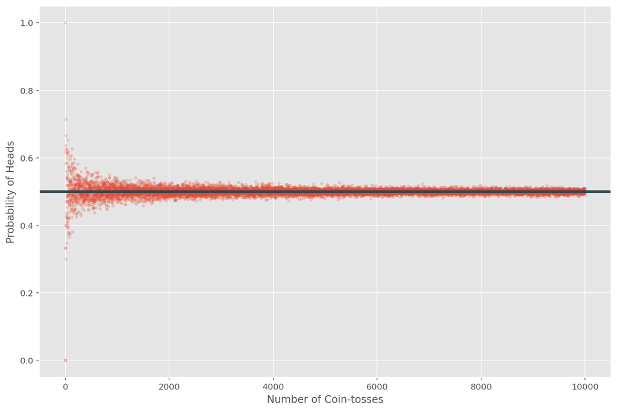

```python
plt.scatter(coin_flip_df['trials'], coin_flip_df['probability'], s=10, alpha=0.2)
plt.axhline(y=0.5, lw=3, color='#36454f')
plt.xlabel('Number of Coin-tosses')
plt.ylabel('Probability of Heads');
```

back to top

# Python Decorators in Classes

[Stackoverflow - Decorators](https://stackoverflow.com/questions/1263451/python-decorators-in-classes)

```python
class Test(object):
    def _decorator(foo):
        def magic( self ) :
            print("start magic")
            foo( self )
            print("end magic")
        return magic

    @_decorator
    def bar( self ) :
        print(">>> normal call")

    _decorator = staticmethod( _decorator )


class TestB( Test ):
    @Test._decorator
    def bar( self ):
        print(">>override bar in")
        super( TestB, self ).bar()
        print(">>override bar out")


print("Normal:")
test = Test()
test.bar()
print()

print("Inherited:")
b = TestB()
b.bar()
print
```

```
Normal:
start magic
>>> normal call
end magic

Inherited:
start magic
>>override bar in
start magic
>>> normal call
end magic
>>override bar out
end magic
```

```
<function print>
```

[OOP Python Turotial](https://www.python-course.eu/python3_properties.php)

```python
class P:

    def __init__(self):
        self._x = None

    @property
    def x(self):
        return self._x

    @x.setter
    def x(self, value):
        if value < 0:
            self._x = 0
        elif value > 1000:
            self._x = 1000
        else:
            self._x = value
```

```python
p1 = P()
p1.x
```

```python
p1.x = -12
p1.x
```

```
0
```

```python
p1.x = 54
p1.x
```

```
54
```

```python
p1.x = 1002
p1.x
```

```
1000
```

### Python Property Decorator - @property

[TutorialsTeacher](https://www.tutorialsteacher.com/python/property-decorator)

```python
class Student:

    def __init__(self, name):
        self.__name = name


    @property
    def name(self):
        return self.__name

    @name.setter   #property-name.setter decorator
    def name(self, value):
        self.__name = value


    @name.deleter  #property-name.deleter decorator
    def name(self):
        print('Deleting..')
        del self.__name
```

```python
s = Student("Steve")

s.name
```

```
'Steve'
```

```python
s.name = 'Bill'
```

```python
s.name
```

```
'Bill'
```

```python
del s.name
```

```
Deleting..
```

```python
s.name
```

```
---------------------------------------------------------------------------
AttributeError                            Traceback (most recent call last)
<ipython-input-41-98b019fbfe94> in <module>
----> 1 s.name

<ipython-input-36-3fdf4196d3dd> in name(self)
      7     @property
      8     def name(self):
----> 9         return self.__name
     10
     11     @name.setter   #property-name.setter decorator

AttributeError: 'Student' object has no attribute '_Student__name'
```

### Python - property() function

[Tutorial](https://www.tutorialsteacher.com/python/property-function)

```python
class Person:

    def __init__(self, name):
        self.__name=name

    def setname(self, name):
        print('setname() called')
        self.__name=name

    def getname(self):
        print('getname() called')
        return self.__name

    def delname(self):
        print('delname() called')
        del self.__name

    # Set property to use get_name, set_name
    # and del_name methods
    name=property(getname, setname, delname)
```

```python
p1 = Person("Jone")
p1.name = "Steve"
```

```
setname() called
```

```python
p1.name
```

```
getname() called
```

```
'Steve'
```

```python
del p1.name
```

```
delname() called
```

[Stackoverflow-property-decorator](https://stackoverflow.com/questions/17330160/how-does-the-property-decorator-work-in-python)

[How Python Properties Help With Refactoring](https://powerfulpython.com/blog/python-properties-refactoring/)

```python
class Money:
    def __init__(self, dollars, cents):
        self.total_cents = dollars * 100 + cents

    # Getter and setter for dollars ...
    @property
    def dollars(self):
        return self.total_cents // 100;

    @dollars.setter
    def dollars(self, new_dollars):
        self.total_cents = 100 * new_dollars + self.cents

    # Add the getter and setter for cents.
    @property
    def cents(self):
        return self.total_cents % 100;

    @cents.setter
    def cents(self, new_cents):
        self.total_cents = 100 * self.dollars + new_cents;
```

```python
money = Money(27, 12)
message = "I have {:d} dollars and {:d} cents."
print(message.format(money.dollars, money.cents))
```

```
I have 27 dollars and 12 cents.
```

```python
money.dollars += 2
money.cents += 20
print(message.format(money.dollars, money.cents))
```

```
I have 29 dollars and 32 cents.
```

```python
money.cents += 112
print(message.format(money.dollars, money.cents))
```

```
I have 30 dollars and 44 cents.
```

back to top

# Python's `super()`

[Stackoverflow example](https://stackoverflow.com/questions/576169/understanding-python-super-with-init-methods/27134600#27134600)

**What difference is there in the codes below?**

```
class ChildA(Base):
    def __init__(self):
        Base.__init__(self)


class ChildB(Base):
    def __init__(self):
        super().__init()
```

The point of `super` is not to avoid writing the parent class. The point is to ensure that the next method in line in the method resolution order (MRO) is called. This becomes important in multiple inheritance.

```python
class Base(object):
    def __init__(self):
        print("Base init'ed")


class ChildA(Base):
    def __init__(self):
        print("ChildA init'ed")
        Base.__init__(self)


class ChildB(Base):
    def __init__(self):
        print("ChildB init'ed")
        super().__init__()
```

And let's create a dependency that we want to be called after the child:

```python
class UserDependency(Base):
    def __init__(self):
        print("UserDependency init'ed")
        super().__init__()
```

Now remember, `ChildB` uses super, `ChildA` does not:

```python
class UserA(ChildA, UserDependency):
    def __init__(self):
        print("UserA init'ed")
        super().__init__()

class UserB(ChildB, UserDependency):
    def __init__(self):
        print("UserB init'ed")
        super().__init__()
```

And `UserA` does not call the UserDependency method:

```python
UserA()
```

```
UserA init'ed
ChildA init'ed
Base init'ed
```

```
<__main__.UserA at 0x2864baf1a60>
```

But `UserB` does in-fact call UserDependency because `ChildB` invokes `super`:

```python
UserB()
```

```
UserB init'ed
ChildB init'ed
UserDependency init'ed
Base init'ed
```

```
<__main__.UserB at 0x2864baf1250>
```

back to top

# Class methods, static methods, and regular instance methods demystified

```python
class MyClass:
    def method(self):
        return 'instance method called', self

    @classmethod
    def classmethod(cls):
        return 'class method called', cls

    @staticmethod
    def staticmethod():
        return 'static method called'
```

```python
obj = MyClass()
obj.method()   # has access to the object instance (printed as <MyClass instance>) via the self argument
```

```
('instance method called', <__main__.MyClass at 0x23816bbe1f0>)
```

```python
MyClass.method(obj)
```

```
('instance method called', <__main__.MyClass at 0x23816bbe1f0>)
```

Instance methods can also access the *class itself* through the `self.__class__` attribute. This makes instance methods powerful in terms of access restrictions -they can modify state on the object instance *and* on the class itself.

```python
obj.classmethod()
```

```
('class method called', __main__.MyClass)
```

The `classmethod` doesn't have access to the object, but only to the object, representing the class itsefl (everything in Python is an object, even classes themselves).

```python
MyClass.classmethod()  # Python automatically passes the class as the first argument to a class method
```

```
('class method called', __main__.MyClass)
```

Note: naming these parameters `self` and `cls` is just a convention. You could just as easily name them `the_object` and `the_class` and get the same result. All that matters is that they're positioned first in the parameter list for the method.

```python
obj.staticmethod()
```

```
'static method called'
```

This confirms that static methods can neither access the obect instance state nor the class state. They work like regular functions but belong to the class's (and very instance's) namespace.

```python
MyClass.classmethod()
```

```
('class method called', __main__.MyClass)
```

```python
MyClass.staticmethod()
```

```
'static method called'
```

```python
MyClass.method() # there is no way for Python to populate the self argument and therefore the call fails
```

```
---------------------------------------------------------------------------
TypeError                                 Traceback (most recent call last)
<ipython-input-11-88f17b4fa117> in <module>
----> 1 MyClass.method()

TypeError: method() missing 1 required positional argument: 'self'
```

```python
MyClass.__dict__
```

```
mappingproxy({'__module__': '__main__',
              'method': <function __main__.MyClass.method(self)>,
              'classmethod': <classmethod at 0x1fbc3f60730>,
              'staticmethod': <staticmethod at 0x1fbc3f60760>,
              '__dict__': <attribute '__dict__' of 'MyClass' objects>,
              '__weakref__': <attribute '__weakref__' of 'MyClass' objects>,
              '__doc__': None})
```

```python
obj.__dict__
```

```
{}
```

```python
obj.__class__.__dict__
```

```
mappingproxy({'__module__': '__main__',
              'method': <function __main__.MyClass.method(self)>,
              'classmethod': <classmethod at 0x1fbc3f60730>,
              'staticmethod': <staticmethod at 0x1fbc3f60760>,
              '__dict__': <attribute '__dict__' of 'MyClass' objects>,
              '__weakref__': <attribute '__weakref__' of 'MyClass' objects>,
              '__doc__': None})
```

```python
type(obj)
```

```
__main__.MyClass
```

**Example:**

```python
class Pizza:
    def __init__(self, ingredients):
        self.ingredients = ingredients


    def __repr__(self):
        return f"Pizza({self.ingredients!r})"


Pizza(['cheese', 'tomatoes'])
```

```
Pizza(['cheese', 'tomatoes'])
```

In older Python versions, the `__repr__` method would have been overriden as follows:

```
def __repr__(self):
    return 'Pizza(%r)' % self.ingredients
```

### Delicious Pizza Factories With `@classmethod`

```python
Pizza(['mozzarella', 'tomatoes'])
```

```
Pizza(['mozzarella', 'tomatoes'])
```

```python
Pizza(['mozzarella', 'tomatoes', 'ham', 'mushrooms'])
```

```
Pizza(['mozzarella', 'tomatoes', 'ham', 'mushrooms'])
```

```python
Pizza(['mozzarella'] * 4)
```

```
Pizza(['mozzarella', 'mozzarella', 'mozzarella', 'mozzarella'])
```

A nice and clean way to do this is by using class methods as factory functions) for the different kinds of pizzas we can create:

```python
class Pizza:
    def __init__(self, ingredients):
        self.ingredients = ingredients


    def __repr__(self):
        return f"Pizza({self.ingredients!r})"

    @classmethod
    def margherita(cls):
        return cls(['mozarella', 'tomatoes'])

    @classmethod
    def prosciutto(cls):
        return cls(['mozarella', 'tomatoes', 'ham'])
```

```python
Pizza.margherita()
```

```
Pizza(['mozarella', 'tomatoes'])
```

```python
Pizza.prosciutto()
```

```
Pizza(['mozarella', 'tomatoes', 'ham'])
```

Python only allows one `__init__` method per class. Using class methods it's possible to add as many alternative constructors as necessary. This can make the interface of your classes self-documenting (to a certain degree) and simplify their usage.

```python
class Pizza:
    def __init__(self, radius, ingredients):
        self.radius = radius
        self.ingredients = ingredients

    def __repr__(self):
        return (f'Pizza({self.radius!r}, '
                f'{self.ingredients!r})')

    def area(self):
        return self.circle_area(self.radius)

    @staticmethod
    def circle_area(r):
        return math.pi * math.pow(r, 2)
```

```python
p = Pizza(4, ['mozzarella', 'tomatoes'])

p
```

```
Pizza(4, ['mozzarella', 'tomatoes'])
```

```python
p.area()
```

```
50.26548245743669
```

```python
Pizza.circle_area(4)
```

```
50.26548245743669
```

back to top

# Class and Instance Attributes

[Class and Instance Attributes](https://www.python-course.eu/python3_class_and_instance_attributes.php)

```python
class AClass:
    a = "I am a class attribute!"

x = AClass()
y = AClass()
```

```python
x.a, y.a, AClass.a
```

```
('I am a class attribute!',
 'I am a class attribute!',
 'I am a class attribute!')
```

> But be careful, if you want to change a class attribute, you have to do it with the notation ClassName.AttributeName. Otherwise, you will create a new instance variable. We demonstrate this in the following example:

```python
x.a = "This creates a new instance attribute for x!"
```

```python
x.a, y.a, AClass.a
```

```
('This creates a new instance attribute for x!',
 'I am a class attribute!',
 'I am a class attribute!')
```

```python
x.__dict__,  y.__dict__,  AClass.__dict__,  x.__class__.__dict__
```

```
({'a': 'This creates a new instance attribute for x!'},
 {},
 mappingproxy({'__module__': '__main__',
               'a': 'I am a class attribute!',
               '__dict__': <attribute '__dict__' of 'AClass' objects>,
               '__weakref__': <attribute '__weakref__' of 'AClass' objects>,
               '__doc__': None}),
 mappingproxy({'__module__': '__main__',
               'a': 'I am a class attribute!',
               '__dict__': <attribute '__dict__' of 'AClass' objects>,
               '__weakref__': <attribute '__weakref__' of 'AClass' objects>,
               '__doc__': None}))
```

In the following example, we demonstrate, how you can count instance with class attributes. All we have to do is

- to create a class attribute, which we call "counter" in our example
- to increment this attribute by 1 every time a new instance is created
- to decrement the attribute by 1 every time an instance is destroyed

```python
class C:

    counter = 0   # public attribute

    def __init__(self):
        type(self).counter += 1   # type(self).countr  <-->  C.counter. type(self) evaluates to C

    def __del__(self):
        type(self).counter -= 1

if __name__ == "__main__":
    x = C()
    print(f"Number of instances: {C.counter}")
    y = C()
    print(f"Number of instances: {C.counter}")
    del x
    print(f"Number of instances: {C.counter}")
    del y
    print(f"Number of instances: {C.counter}")
```

```
Number of instances: 1
Number of instances: 2
Number of instances: 1
Number of instances: 0
```

```python
class Robot:
    __counter = 0   # private attribute

    def __init__(self):
        type(self).__counter += 1

    def RobotInstances(self):
        return Robot.__counter


if __name__ == "__main__":
    x = Robot()
    print(x.RobotInstances())
    y = Robot()
    print(x.RobotInstances())
```

```
1
2
```

```python
y.RobotInstances()
```

```
2
```

```python
class Robot:
    __counter = 0

    def __init__(self):
        type(self).__counter += 1

    @staticmethod
    def RobotInstances():
        return Robot.__counter


if __name__ == "__main__":
    print(Robot.RobotInstances())
    x = Robot()
    print(x.RobotInstances())
    y = Robot()
    print(x.RobotInstances())
    print(Robot.RobotInstances())
```

```
0
1
2
2
```

Static methods shouldn't be confused with class methods. Like static methods class methods are not bound to instances, but unlike static methods class methods are bound to a class. The first parameter of a class method is a reference to a class, i.e. a class object. They can be called via an instance or the class name.

```python
class Robot:
    __counter = 0

    def __init__(self):
        type(self).__counter += 1

    @classmethod
    def RobotInstances(cls):
        return cls, Robot.__counter


if __name__ == "__main__":
    print(Robot.RobotInstances())
    x = Robot()
    print(x.RobotInstances())
    y = Robot()
    print(x.RobotInstances())
    print(Robot.RobotInstances())
```

```
(<class '__main__.Robot'>, 0)
(<class '__main__.Robot'>, 1)
(<class '__main__.Robot'>, 2)
(<class '__main__.Robot'>, 2)
```

The use cases of class methods:

- They are used in the definition of the so-called factory methods.
- They are often used, where we have static methods, which have to call other static methods. To do this, we would have to hard code the class name, if we had to use static methods. This is a problem, if we are in a use case, where we have inherited classes.

The following program contains a fraction class, which is still not complete. If you work with fractions, you need to be capable of reducing fractions, e.g. the fraction 8/24 can be reduced to 1/3. We can reduce a fraction to lowest terms by dividing both the numerator and denominator by the Greatest Common Divisor (GCD).

```python
class fraction(object):

    def __init__(self, n, d):
        self.numerator, self.denominator = fraction.reduce(n, d)


    @staticmethod
    def gcd(a,b):
        while b != 0:
            a, b = b, a%b
        return a

    @classmethod
    def reduce(cls, n1, n2):
        g = cls.gcd(n1, n2)
        return (n1 // g, n2 // g)

    def __str__(self):
        return f"{self.numerator}/{self.denominator}"
```

```python
x = fraction(54, 42)
print(x)
```

```
9/7
```

back to top

# Abstract Classes in Python

[Abstract Classes in Python](https://www.geeksforgeeks.org/abstract-classes-in-python/)

```python
# Python program showing
# abstract base class work

from abc import ABC, abstractmethod

class Polygon(ABC):

    @abstractmethod
    def noofsides(self):
        pass


class Triangle(Polygon):

    # overriding abstract method
    def noofsides(self):
        print("I have 3 sides")


class Pentagon(Polygon):

    # overriding abstract method
    def noofsides(self):
        print("I have 5 sides")


class Hexagon(Polygon):

    # overriding abstract method
    def noofsides(self):
        print("I have 6 sides")


class Quadrilateral(Polygon):

    # overriding abstract method
    def noofsides(self):
        print("I have 4 sides")


# Driver code
R = Triangle()
R.noofsides()

K = Quadrilateral()
K.noofsides()

R = Pentagon()
R.noofsides()

K = Hexagon()
K.noofsides()
```

```
I have 3 sides
I have 4 sides
I have 5 sides
I have 6 sides
```

back to top

## What is the difference between `floor()` and `int()`?

`floor()` rounds *down*. `int()` *truncates*. The difference is clear when you use negative numbers:

```python
import math

math.floor(-3.5)
```

```
-4
```

```python
int(-3.5)
```

```
-3
```

back to top

## Hadamard product (of matrices)

In mathematics, the **Hadamard product** (also known as the **element-wise**, **entrywise** or **Schur product**) is a binary operation that takes two matrices of the same dimensions and produces another matrix of the same dimension as the operands where each element i, j is the product of elements i, j of the original two matrices. It should not be confused with the more common matrix product. It is attributed to, and named after, either French mathematician Jacques Hadamard or German mathematician Issai Schur.

The Hadamard product is associative and distributive. Unlike the matrix product, it is also commutative.

For two matrices A and B of the same dimension m × n, the Hadamard product ${\displaystyle A\circ B}$ (or ${\displaystyle A\odot B}$) is a matrix of the same dimension as the operands, with elements given by

$${\displaystyle (A\circ B)_{ij}=(A\odot B)_{ij}=(A)_{ij}(B)_{ij}.}$$

back to top

## Random numbers

Python defines a set of functions that are used to generate or manipulate random numbers. This particular type of functions are used in a lot of games, lotteries or any application requiring random number generation.

Randon Number Operations :

1. choice() :- This function is used to generate 1 random number from a container.
2. randrange(beg, end, step) :- This function is also used to generate random number but within a range specified in its arguments. This function takes 3 arguments, beginning number (included in generation), last number (excluded in generation) and step ( to skip numbers in range while selecting).

```python
# Python code to demonstrate the working of
# choice() and randrange()

# importing "random" for random operations
import random

# using choice() to generate a random number from a
# given list of numbers.
print ("A random number from list is : ",end="")
print (random.choice([1, 4, 8, 10, 3]))

# using randrange() to generate in range from 20
# to 50. The last parameter 3 is step size to skip
# three numbers when selecting.
print ("A random number from range is : ",end="")
print (random.randrange(20, 50, 3))
```

```
A random number from list is : 3
A random number from range is : 47
```

1. random() :- This number is used to generate a float random number less than 1 and greater or equal to 0.
2. seed() :- This function maps a particular random number with the seed argument mentioned. All random numbers called after the seeded value returns the mapped number.

```python
# Python code to demonstrate the working of
# random() and seed()

# importing "random" for random operations
import random

# using random() to generate a random number
# between 0 and 1
print ("A random number between 0 and 1 is : ", end="")
print (random.random())

# using seed() to seed a random number
random.seed(5)

# printing mapped random number
print ("The mapped random number with 5 is : ", end="")
print (random.random())

# using seed() to seed different random number
random.seed(7)

# printing mapped random number
print ("The mapped random number with 7 is : ", end="")
print (random.random())

# using seed() to seed to 5 again
random.seed(5)

# printing mapped random number
print ("The mapped random number with 5 is : ",end="")
print (random.random())

# using seed() to seed to 7 again
random.seed(7)

# printing mapped random number
print ("The mapped random number with 7 is : ",end="")
print (random.random())
```

```
A random number between 0 and 1 is : 0.10414792522978578
The mapped random number with 5 is : 0.6229016948897019
The mapped random number with 7 is : 0.32383276483316237
The mapped random number with 5 is : 0.6229016948897019
The mapped random number with 7 is : 0.32383276483316237
```

1. shuffle() :- This function is used to shuffle the entire list to randomly arrange them.
2. uniform(a, b) :- This function is used to generate a floating point random number between the numbers mentioned in its arguments. It takes two arguments, lower limit(included in generation) and upper limit(not included in generation).

```python
# Python code to demonstrate the working of
# shuffle() and uniform()

# importing "random" for random operations
import random

# Initializing list
li = [1, 4, 5, 10, 2]

# Printing list before shuffling
print ("The list before shuffling is : ", end="")
for i in range(0, len(li)):
    print (li[i], end=" ")
print("\r")

# using shuffle() to shuffle the list
random.shuffle(li)

# Printing list after shuffling
print ("The list after shuffling is : ", end="")
for i in range(0, len(li)):
    print (li[i], end=" ")
print("\r")

# using uniform() to generate random floating number in range
# prints number between 5 and 10
print ("The random floating point number between 5 and 10 is : ",end="")
print (random.uniform(5,10))
```

```
The list before shuffling is : 1 4 5 10 2
The list after shuffling is : 2 1 5 10 4
The random floating point number between 5 and 10 is : 5.362181433337714
```

back to top

## String Punctuation

```python
print(punctuation)
```

```
!"#$%&'()*+,-./:;<=>?@[\]^_`{|}~
```

```python
# txt = ' '.join(txt.split(" "))
```

```python
with open('./data/punctuation_example.txt','w',  encoding='utf-16') as f:
    f.write(txt)
```

```python
with open('./data/punctuation_example.txt', 'r', encoding='utf-16') as f:
    txt = f.read()
```

```python
''.join([c for c in txt if c not in punctuation])
```

```
'Other languages of Europe use much the same punctuation as English The similarity is so strong that the few variations may confuse a native English reader Quotation marks are particularly variable across European languages For example in French and Russian quotes would appear as «Je suis fatigué» i…
```

```python
dct = Counter(txt)

sorted_dct = []

for k in sorted(dct, key=dct.get, reverse=True):
    sorted_dct.append((k, dct.get(k)))

sorted_dct
```

```
[(' ', 443),
 ('e', 239),
 ('n', 198),
 ('a', 196),
 ('t', 175),
 ('i', 153),
 ('r', 143),
 ('s', 140),
 ('o', 131),
 ('u', 82),
 ('h', 78),
 ('l', 77),
 ('c', 65),
 ('d', 64),
 ('m', 56),
 ('f', 38),
 ('p', 38),
 (',', 38),
 ('g', 36),
 ('.', 27),
 ('b', 25),
 ('w', 23),
 ('v', 20),
 ('y', 18),
 ('k', 18),
 ('\n', 18),
 ('⟨', 15),
 ('⟩', 15),
 ('I', 11),
 ('x', 8),
 ('q', 8),
 ('E', 7),
 ('F', 6),
 (':', 6),
 ('R', 5),
 ('-', 5),
 (';', 5),
 ('2', 5),
 ('S', 4),
 ('A', 4),
```

[output cut: 35 more lines]

```
 ('՞', 1),
 ('U', 1),
 ('؟', 1),
 ('،', 1),
 ('H', 1),
 ('7', 1),
 ('D', 1),
 ('।', 1),
 ('॥', 1),
 ('W', 1),
 ('9', 1),
 ('[', 1),
 (']', 1),
 ('B', 1),
 ('j', 1)]
```

back to top

## Enumerate

```python
my_list = 'apple banana grapes pear'.split()
```

```python
for counter, value in enumerate(my_list):
    print(counter, value)
```

```
0 apple
1 banana
2 grapes
3 pear
```

```python
for counter, value in enumerate(my_list, 1):
    print(counter, value)
```

```
1 apple
2 banana
3 grapes
4 pear
```

```python
for counter, value in enumerate(my_list, 5):
    print(counter, value)
```

```
5 apple
6 banana
7 grapes
8 pear
```

back to top

## The `re` module

> 14 meta-characters (in the `re` module): `. ? * + ^ $ [ ] ( ) { } | \`

> `.`: matches anything except newline  
> `?`: matches 0 or 1 character  
> `*`: matches 0 or more characters  
> `+`: matches 1 or more characters  
> `[]`: character set  
> `()`: group  
> `{}`: number of times  
> `^`: begins with  
> `$`: ends with

> `\d`: digits <=> `[0-9]`  
> `\D`: non-digits <=> `[^0-9]`  
> `\s`: white space <=> `[\t\n\r\f\v]`  
> `\S`: nonwhite space <=> `[^\t\n\r\f\v]`  
> `\w`: alphanumeric <=> `[a-zA-Z0-9]`  
> `\W`: non-alphanumeric <=> `[^a-zA-Z0-9]`  
> `\b`: non-alphanumeric boundary  
> `\B`: alphanumeric boundary

### More on Regular Expressions

> [regex-python-part-1](https://realpython.com/regex-python/)  
> [regex-python-part-2](https://realpython.com/regex-python-part-2/)  
> [regular expression HOWTO](https://docs.python.org/3/howto/regex.html)  
> [More on regular expressions](https://www.cs.wcupa.edu/rkline/index/regular-expressions.html#examples)  
> [w3-schools](https://www.w3schools.com/python/python_regex.asp)  
> [regex101](https://regex101.com/r/S2CbwM/1)

### URL_regex

> `url_regex = 'http[s]?://(?:[a-zA-Z]|[0-9]|[$-_@.&+]|[!*\(\),]|(?:%[0-9a-fA-F][0-9a-fA-F]))+'`

back to top

## CSV Files - read / write

```
import csv

with open("filtered.csv", "w", newline="") as f:
    writer = csv.writer(f)
    writer.write
```

```
import csv

filtered = []
with open('filtered.csv') as csvfile:
    reader = csv.reader(csvfile)
    for row in reader:
        filtered.append(row)

filtered[:5]
```

```python
np.random.randint(0,10,(3,4))
```

```
array([[2, 1, 5, 6],
       [9, 1, 0, 3],
       [7, 2, 7, 4]])
```

```python
-8/13*ln(8/13) - 3/13*ln(3/13) - 2/13 * ln(2/13)
```

```
0.9251290835720823
```

back to top

## SQLite

```
# write df to a csv file
if df.shape[0] != 0:
    with open("output/momentum_stocks.csv", "a") as file:
        for index, row in df.iterrows():
            row = ("{tic},{nm},{pr},{cumrt},{ncumrt},{sntm},{snpdt}\n"
                   .format(tic=row['Ticker'],
                       nm=row['Name'],
                       pr=row['Price'],
                       cumrt=row['CumRet'],
                       ncumrt=row['NegCumRetCnt'],
                       sntm=row['Sentiment'],
                       snpdt=row['snap_dt']))
            file.write(row)

# write df to a sqlite db
con = sqlite3.connect("output/momentumstocks.db")
cur = con.cursor()

cur.execute("DROP TABLE IF EXISTS stocks;")

cur.execute("""
    CREATE TABLE stocks (
    id INTEGER PRIMARY KEY,
    ticker TEXT NOT NULL,
    company_name TEXT NOT NULL,
    price Decimal(5,2) NOT NULL,
    cumulative_return DECIMAL(5,2) NOT NULL,
    negative_cumulative_return DECIMAL(5,2) NOT NULL,
    sentiment TEXT,
    snap_date DATE);
    """)
```

```
insert_string = "INSERT INTO stocks (ticker, company_name, \
price, cumulative_return, negative_cumulative_return, sentiment, \
snap_date) VALUES (?, ?, ?, ?, ?, ?, ?);"

if df.shape[0] == 0:
    print("No momentum stocks found.")
else:
    try:
        for row in df.values:
            cur.execute(insert_string, tuple(row))
            print(tuple(row), "inserted...")
    except Exception as e:
        print(e)

    finally:
        con.commit()
        con.close()
```

```
con = sqlite3.connect("bullishstocks.db")
cur = con.cursor()

# cur.execute("SELECT * FROM stocks").fetchall()

for row in cur.execute("SELECT * FROM stocks LIMIT 10"):
    print(row)

con.close()
```

```
con = sqlite3.connect("bullishstocks.db")
cur = con.cursor()

# list of all tables in current db
cur.execute("SELECT name FROM sqlite_master WHERE type='table'").fetchall()

# list of columns in table table_name
cur.execute("SELECT name FROM PRAGMA_TABLE_INFO('table_name');").fetchall()


con.close()
```

```
import pandas as pd
import sqlalchemy
import psycopg2

engine = sqlalchemy.create_engine("postgresql+psycopg2://...")

the_frame = pd.read_sql_query("SELECT * FROM %s;" % name_of_table, engine)
the_frame = pd.read_sql_table(name_of_table, engine)
```

```
engine = create_engine('sqlite:///DisasterResponse.db')

df.to_sql('messages', engine, if_exists='replace', index=False)

engine.execute("SELECT * FROM messages LIMIT 3").fetchall()

df = pd.read_sql_table('messages', engine)

`
```

## np.nansum

[`np.nansum`](https://numpy.org/doc/stable/reference/generated/numpy.nansum.html)

`numpy.nansum(a, axis=None, dtype=None, out=None, keepdims=<no value>)`

Return the sum of array elements over a given axis treating Not a Numbers (NaNs) as zero.

In NumPy versions <= 1.9.0 Nan is returned for slices that are all-NaN or empty. In later versions zero is returned.

```python
np.nansum(1)
```

```
1
```

```python
np.nansum([1])
```

```
1
```

```python
np.nansum([1, np.nan])
```

```
1.0
```

```python
a = np.array([[1, 1], [1, np.nan]])
np.nansum(a)
```

```
3.0
```

```python
np.nansum(a, axis=0)
```

```
array([2., 1.])
```

back to top

```python
df = pd.DataFrame(data=np.random.random(size=(5,3)), columns='A B C'.split())
```

```python
pd.concat([df]*5).reset_index().sort_values(by='index').set_index('index').head(20)
```

| index | A | B | C |
| --- | --- | --- | --- |
| 0 | 0.110888 | 0.419406 | 0.729538 |
| 0 | 0.110888 | 0.419406 | 0.729538 |
| 0 | 0.110888 | 0.419406 | 0.729538 |
| 0 | 0.110888 | 0.419406 | 0.729538 |
| 0 | 0.110888 | 0.419406 | 0.729538 |
| 1 | 0.102668 | 0.785943 | 0.533054 |
| 1 | 0.102668 | 0.785943 | 0.533054 |
| 1 | 0.102668 | 0.785943 | 0.533054 |
| 1 | 0.102668 | 0.785943 | 0.533054 |
| 1 | 0.102668 | 0.785943 | 0.533054 |
| 2 | 0.659041 | 0.717909 | 0.181287 |
| 2 | 0.659041 | 0.717909 | 0.181287 |
| 2 | 0.659041 | 0.717909 | 0.181287 |
| 2 | 0.659041 | 0.717909 | 0.181287 |
| 2 | 0.659041 | 0.717909 | 0.181287 |
| 3 | 0.994850 | 0.959694 | 0.992906 |
| 3 | 0.994850 | 0.959694 | 0.992906 |
| 3 | 0.994850 | 0.959694 | 0.992906 |
| 3 | 0.994850 | 0.959694 | 0.992906 |
| 3 | 0.994850 | 0.959694 | 0.992906 |

back to top

## Naming with Underscores in Python

[Article by Rachit Tayal here on Medium](https://medium.com/python-features/naming-conventions-with-underscores-in-python-791251ac7097)

## random.shuffle, random.random, random.choice, random.choices

```python
import random
from random import randint
```

```python
cards = [11, 2, 3, 4, 5, 6, 7, 8, 9, 10, 10, 10, 10]
```

```python
crd = sorted(cards)
```

```python
crd
```

```
[2, 3, 4, 5, 6, 7, 8, 9, 10, 10, 10, 10, 11]
```

```python
cards
```

```
[11, 2, 3, 4, 5, 6, 7, 8, 9, 10, 10, 10, 10]
```

```python
random.choices(cards, k=2)
```

```
[5, 8]
```

```python
random.choice(cards)
```

```
4
```

```python
for _ in range(25):
    print(randint(1,6), end=' ')
```

```
5 6 4 6 1 6 6 2 6 5 4 4 4 1 2 6 6 3 2 1 6 6 6 4 2
```

## Ordinary Least Squares

https://www.statsmodels.org/dev/examples/notebooks/generated/ols.html

```python
nsample = 100
x = np.linspace(0, 10, 100)
X = np.column_stack((x, x**2))
beta = np.array([1, 0.1, 10])
e = np.random.normal(size=nsample)
```

```python
# Our model needs an intercept so we add a column of 1s:
X = sm.add_constant(X)
y = np.dot(X, beta) + e
```

```python
# Fit and summary:
model = sm.OLS(y, X)
results = model.fit()

print(results.summary())
```

```
                            OLS Regression Results
==============================================================================
Dep. Variable:                      y   R-squared:                       1.000
Model:                            OLS   Adj. R-squared:                  1.000
Method:                 Least Squares   F-statistic:                 3.893e+06
Date:                Sat, 24 Oct 2020   Prob (F-statistic):          1.35e-238
Time:                        11:59:19   Log-Likelihood:                -148.17
No. Observations:                 100   AIC:                             302.3
Df Residuals:                      97   BIC:                             310.2
Df Model:                           2
Covariance Type:            nonrobust
==============================================================================
                 coef    std err          t      P>|t|      [0.025      0.975]
------------------------------------------------------------------------------
const          1.2301      0.318      3.869      0.000       0.599       1.861
x1            -0.0388      0.147     -0.264      0.792      -0.330       0.253
x2            10.0148      0.014    704.293      0.000       9.987      10.043
==============================================================================
Omnibus:                        1.756   Durbin-Watson:                   2.184
Prob(Omnibus):                  0.416   Jarque-Bera (JB):                1.192
Skew:                          -0.174   Prob(JB):                        0.551
Kurtosis:                       3.407   Cond. No.                         144.
==============================================================================

Warnings:
[1] Standard Errors assume that the covariance matrix of the errors is correctly specified.
```

```python
dir(results)
```

```
['HC0_se',
 'HC1_se',
 'HC2_se',
 'HC3_se',
 '_HCCM',
 '__class__',
 '__delattr__',
 '__dict__',
 '__dir__',
 '__doc__',
 '__eq__',
 '__format__',
 '__ge__',
 '__getattribute__',
 '__gt__',
 '__hash__',
 '__init__',
 '__init_subclass__',
 '__le__',
 '__lt__',
 '__module__',
 '__ne__',
 '__new__',
 '__reduce__',
 '__reduce_ex__',
 '__repr__',
 '__setattr__',
 '__sizeof__',
 '__str__',
 '__subclasshook__',
 '__weakref__',
 '_cache',
 '_data_attr',
 '_get_robustcov_results',
 '_is_nested',
 '_use_t',
 '_wexog_singular_values',
 'aic',
 'bic',
 'bse',
```

[output cut: 44 more lines]

```
 'rsquared',
 'rsquared_adj',
 'save',
 'scale',
 'ssr',
 'summary',
 'summary2',
 't_test',
 't_test_pairwise',
 'tvalues',
 'uncentered_tss',
 'use_t',
 'wald_test',
 'wald_test_terms',
 'wresid']
```

```python
print(f'Parameters: {results.params}')
print(f'R2: {results.rsquared}')
```

```
Parameters: [ 1.23009916 -0.03881786 10.01481225]
R2: 0.9999875413415946
```

back to top

## Pickle & JSON file formats

```
# TODO Implement
import pickle
from tqdm import tqdm

try:
    print("Loading existing twits dataset")
    tokenized = pickle.load(open("tokenized.p", "rb"))
except:
    print("Failed! Preprocess new twits dataset")
    tokenized = [preprocess(twits) for twits in tqdm(messages)]
    pickle.dump(tokenized, open("tokenized.p", "wb"))
```

# echo http proxy (CLI)

`echo $http_proxy`

# CI/CD

**CI/CD** tools = Continuous Integration and Continuous Delivery tools

# Clean up spaces

```python
input_text = """
A passionate data scientist with broad and in-depth programming, mathematics,
and statistics skills and an aptitude for translating complex data problems
into apprehensible insights. On a daily basis, I leverage these skillsets and
use various data analytics and data visualization tools such as Python, R, Pyspark,
Spark SQL, Snowflake, Databricks, AWS, GitHub, etc. to solve business and data problems.
I am also very passionate about AI, machine learning, data mining and predictive modeling,
and I am highly skilled in using these tools and creating ETL pipelines, machine learning
pipelines and web applications. I have more than 3 years of experience in data analytics and over 10 years of experience in teaching a wide range of
mathematics and statistics courses at a college level.
"""


def clean_up_spaces(text):
    text = " ".join([word for word in text.split() if word !=''])
    print(text)


clean_up_spaces(input_text)
```

```
A passionate data scientist with broad and in-depth programming, mathematics, and statistics skills and an aptitude for translating complex data problems into apprehensible insights. On a daily basis, I leverage these skillsets and use various data analytics and data visualization tools such as Pyth…
```

back to top

## Scratch work

```python
def my_portfolio_value(APPS=32.79, EXPI=39.57, DDOG=85.60):
    '''
    :params: APPS - share price of APPS stock
    :params: EXPI - share price of EXPI stock
    :parames: DDOG - share price of DDOG stock

    :returns: total value of portfolio
    '''
    total_portfolio_value = 190 * APPS + 136 * EXPI + 61 * DDOG
    print("APPS {:.2f}, EXPI {:.2f}, DDOG {:.2f} => total {:.2f}".format(APPS * 190,
                                                                          EXPI * 136, DDOG * 61,
                                                                            total_portfolio_value))
    return total_portfolio_value
```

```python
retr = my_portfolio_value(30.20, 38.36, 88.55); retr
```

```
APPS 5738.00, EXPI 5216.96, DDOG 5401.55 => total 16356.51
```

```
16356.509999999998
```

```python
assert retr > 17000, "your portfolio value is less than $17000"
```

```
---------------------------------------------------------------------------
AssertionError                            Traceback (most recent call last)
<ipython-input-28-53799d25c3d9> in <module>
----> 1 assert retr > 17000, "your portfolio value is less than $17000"

AssertionError: your portfolio value is less than $17000
```

```python
help(my_portfolio_value)
```

```
Help on function my_portfolio_value in module __main__:

my_portfolio_value(APPS=32.79, EXPI=39.57, DDOG=85.6)
    :params: APPS - share price of APPS stock
    :params: EXPI - share price of EXPI stock
    :parames: DDOG - share price of DDOG stock

    :returns: total value of portfolio
```

back to top

```python
regex = re.compile(r"\d+\.?(\d+)?")
```

```python
my_input = '26.93^^^235---'
float(next(regex.finditer(my_input)).group())
```

```
26.93
```

```python
np.zeros((2, 3), dtype=int)
```

```
array([[0, 0, 0],
       [0, 0, 0]])
```

```python
x = np.sqrt(461)
```

```python
(1-x)/2., (1+x)/2.
```

```
(-10.235455276791944, 11.235455276791944)
```

```python
750 * 35
```

```
26250
```

```python
9/25
```

```
0.36
```

```python
24442/60
```

```
407.3666666666667
```

```python
407 / 60
```

```
6.783333333333333
```

```python
math.factorial(0)
```

```
1
```

```python
df1 = (pd.DataFrame(data=np.random.random((5,2)),
             index='a b c d e'.split()).reset_index()
.rename(columns={'index': 'id', 0:'A', 1:'B'}))
```

```python
df2 = (pd.DataFrame(data=np.random.random((5,2)),
             index='a b c d e'.split()).reset_index()
.rename(columns={'index': 'id', 0:'C', 1:'D'}))
```

```python
df1
```

|  | id | A | B |
| --- | --- | --- | --- |
| 0 | a | 0.186182 | 0.353625 |
| 1 | b | 0.494265 | 0.619655 |
| 2 | c | 0.662365 | 0.104692 |
| 3 | d | 0.565938 | 0.023396 |
| 4 | e | 0.232553 | 0.382553 |

```python
df2
```

|  | id | C | D |
| --- | --- | --- | --- |
| 0 | a | 0.069160 | 0.574823 |
| 1 | b | 0.884461 | 0.297173 |
| 2 | c | 0.121612 | 0.634305 |
| 3 | d | 0.583080 | 0.900476 |
| 4 | e | 0.640096 | 0.600894 |

```python
df1.merge(df2, on='id')
```

|  | id | A | B | C | D |
| --- | --- | --- | --- | --- | --- |
| 0 | a | 0.186182 | 0.353625 | 0.069160 | 0.574823 |
| 1 | b | 0.494265 | 0.619655 | 0.884461 | 0.297173 |
| 2 | c | 0.662365 | 0.104692 | 0.121612 | 0.634305 |
| 3 | d | 0.565938 | 0.023396 | 0.583080 | 0.900476 |
| 4 | e | 0.232553 | 0.382553 | 0.640096 | 0.600894 |

```python
list(df1)
```

```
['id', 'A', 'B']
```

```python
1e9
```

```
1000000000.0
```

```python
a = data=np.empty((5,2))
a[:] = np.nan
pd.DataFrame(a)
```

|  | 0 | 1 |
| --- | --- | --- |
| 0 | NaN | NaN |
| 1 | NaN | NaN |
| 2 | NaN | NaN |
| 3 | NaN | NaN |
| 4 | NaN | NaN |

```python
pd.DataFrame(index=list('ABC'))
```

| A |
| --- |
| B |
| C |

back to top

```python
names = ['Hailu Teju', 'Hailu Megersa', 'Chala Teju', 'Hammer Takele', 'Hailat Teju']

list(filter(lambda x: x.endswith('Teju'), names))
```

```
['Hailu Teju', 'Chala Teju', 'Hailat Teju']
```

```python
list(map(str.lower, names))
```

```
['hailu teju', 'hailu megersa', 'chala teju', 'hammer takele', 'hailat teju']
```

```python
def weird_func(a, b):
    def weird_in_func(x):
        return a * (x - b)
    return weird_in_func
```

```python
weird_func(2, 5)(3)
```

```
-4
```

```python
text = "Hailu Teju"
[word for word in text.split()]
```

```
['Hailu', 'Teju']
```

```python
[name for names in [["Hailu", "Teju"], ["Zena", "Bezabih"]] for name in names]
```

```
['Hailu', 'Teju', 'Zena', 'Bezabih']
```

```python
bids = {"hailu": '$120', "hawi": '$520'}

bids_formater = lambda amt: float(amt.replace('$', ''))

formatted_bids = list(map(bids_formater, bids.values()))
max(formatted_bids)
```

```
520.0
```

```python
list(bids.values())
```

```
['$120', '$520']
```

```python
master_shopping_list =sorted(list(set("""laundary_detergent coffee oil onion lamb bananas strawberries chicken milk paprika carrots \
spinach_baby yogurt_greek eggs turkey_sliced baking_soda lysol_all_purpose_cleaner potato cumin_powder \
milk_almond potato potato_sweet tomato bell_pepper garlic oatmeal tomato_paste spinach corn chicken_tigh chicken_drumstick \
turkey_breast pasta flour sugar pesto butter veggie_straws ricola_cough_drops baking_soda strawberries lemon bananas \
avocado coffee oil lentils beer wine quinoa peanut_butter paprika cinnamon noddles_spicy noddles_regular cheese_mozzerella \
cereal_cheerios coffee_filters vinegar protein_shake_kids protein_shake toothpaste mouthwash toilet_paper paper_towel \
trash_bags palmolive_dish_soap potato_sweet turkey_whole pumpkin_pie butter_unsalted pecans potatos cornbread_mix""".split())))

master_shopping_list
```

```
['avocado',
 'baking_soda',
 'bananas',
 'beer',
 'bell_pepper',
 'butter',
 'butter_unsalted',
 'carrots',
 'cereal_cheerios',
 'cheese_mozzerella',
 'chicken',
 'chicken_drumstick',
 'chicken_tigh',
 'cinnamon',
 'coffee',
 'coffee_filters',
 'corn',
 'cornbread_mix',
 'cumin_powder',
 'eggs',
 'flour',
 'garlic',
 'lamb',
 'laundary_detergent',
 'lemon',
 'lentils',
 'lysol_all_purpose_cleaner',
 'milk',
 'milk_almond',
 'mouthwash',
 'noddles_regular',
 'noddles_spicy',
 'oatmeal',
 'oil',
 'onion',
 'palmolive_dish_soap',
 'paper_towel',
 'paprika',
 'pasta',
 'peanut_butter',
```

[output cut: 11 more lines]

```
 'spinach_baby',
 'strawberries',
 'sugar',
 'toilet_paper',
 'tomato',
 'tomato_paste',
 'toothpaste',
 'trash_bags',
 'turkey_breast',
 'turkey_sliced',
 'turkey_whole',
 'veggie_straws',
 'vinegar',
 'wine',
 'yogurt_greek']
```

```python
question = {"category": "Science & Nature",
 "type": "multiple",
 "difficulty": "easy",
 "question": "Which of the following bones is not in the leg?",
 "correct_answer": "Radius",
 "incorrect_answers": ["Patella", "Tibia", "Fibula "]}
```

```python
from random import shuffle

answer_choices = question["incorrect_answers"] + [question["correct_answer"]]
```

```python
shuffle(answer_choices)
```

```python
choices = dict(zip("A B C D".split(), answer_choices)  )
```

```python
choices
```

```
{'A': 'Patella', 'B': 'Tibia', 'C': 'Radius', 'D': 'Fibula '}
```

```python
class Question:

    def __init__(self, q_category, q_type, q_difficulty, q_text, q_answer, q_inc_answer):
        self.category = q_category
        self.type = q_type
        self.difficulty = q_difficulty
        self.question = q_text
        self.correct_answer = q_answer
        self.incorrect_answer = q_inc_answer
```

```python
''.lower() == 'hailu'
```

```
False
```

```python
colors = ['Blue','BlueViolet','Brown','CadetBlue','Chartreuse','Chocolate','Coral','CornflowerBlue',
          'Crimson','Cyan','DarkBlue','DarkCyan','DarkGoldenRod','DarkGray','DarkGreen','DarkKhaki',
          'DarkMagenta','DarkOliveGreen','DarkOrange','DarkOrchid','DarkRed','DarkSalmon','DarkSeaGreen',
          'DarkSlateBlue','DarkTurquoise','DarkViolet','DeepPink','DeepSkyBlue','DimGrey','DodgerBlue',
          'FireBrick','ForestGreen','Fuchsia','Green','IndianRed','Indigo','LawnGreen','LightCoral',
          'LightSalmon','LimeGreen','Maroon','MediumAquaMarine','MediumBlue','MediumOrchid','MediumPurple',
          'MediumSpringGreen','MediumTurquoise','Navy','Olive','OliveDrab','Orange','OrangeRed','Orchid',
          'PaleVioletRed','Peru','Plum','Purple','RebeccaPurple','RoyalBlue','SeaGreen','Sienna','SlateBlue',
          'SpringGreen','SteelBlue','Tan','Teal','Turquoise','Yellow']
```

```python
colors = list(set(colors))
```

```python
sorted(colors)
```

```
['Blue',
 'BlueViolet',
 'Brown',
 'CadetBlue',
 'Chartreuse',
 'Chocolate',
 'Coral',
 'CornflowerBlue',
 'Crimson',
 'Cyan',
 'DarkBlue',
 'DarkCyan',
 'DarkGoldenRod',
 'DarkGray',
 'DarkGreen',
 'DarkKhaki',
 'DarkMagenta',
 'DarkOliveGreen',
 'DarkOrange',
 'DarkOrchid',
 'DarkRed',
 'DarkSalmon',
 'DarkSeaGreen',
 'DarkSlateBlue',
 'DarkTurquoise',
 'DarkViolet',
 'DeepPink',
 'DeepSkyBlue',
 'DimGrey',
 'DodgerBlue',
 'FireBrick',
 'ForestGreen',
 'Fuchsia',
 'Green',
 'IndianRed',
 'Indigo',
 'LawnGreen',
 'LightCoral',
 'LightSalmon',
 'LimeGreen',
```

[output cut: 13 more lines]

```
 'PaleVioletRed',
 'Peru',
 'Plum',
 'Purple',
 'RebeccaPurple',
 'RoyalBlue',
 'SeaGreen',
 'Sienna',
 'SlateBlue',
 'SpringGreen',
 'SteelBlue',
 'Tan',
 'Teal',
 'Turquoise',
 'Yellow']
```

```python
check_mark = "✔"
```

```python
check_mark * 0
```

```
''
```

```python
3 // 2
```

```
1
```

```python
stocks_dict = {}
stocks_list = []
superlist = ['A AGILENT TECHNOLOGIES INC\nAA ALCOA CORPORATION\nAACG ATA CREATIVITY GLOBAL SPON ADS EACH REP 2 ORD SHS\nAACQ ARTIUS ACQUISITION INC\nAACQU ARTIUS ACQUISITION INC UNIT 1 COM & 1/3 WT EXP(13/07/2025)\nAAIC ARLINGTON ASSET INVESTMENT CORP\nAAICpB ARLINGTON ASSET INVESTMENT CORP 7% CUM PRF 12/05/2022 SER B USD25\nAAICpC ARLINGTON ASSET INVESTMENT CORP 8.250%CUM RED FIX TO FLT RATE SR C USD25\nAAL AMERICAN AIRLINES GROUP INC\nAAMC ALTISOURCE ASSET MANAGEMENT CORP', 'AAME ATLANTIC AMERICAN CORP\nAAN THE AARONS COMPANY INC\nAAOI APPLIED OPTOELECTRONICS INC\nAAON AAON INC\nAAP ADVANCE AUTO PARTS INC\nAAPL APPLE INC\nAAT AMERICAN ASSETS TRUST INC\nAAU ALMADEN MINERALS LTD\nAAWW ATLAS AIR WORLDWIDE HOLDINGS INC\nAAXN AXON ENTERPRISE INC', 'AB ALLIANCEBERNSTEIN HOLDING LP\nABB ABB LTD SPON ADR EACH REP 1 ORD SHS\nABBV ABBVIE INC\nABC AMERISOURCEBERGEN CORPORATION\nABCB AMERIS BANCORP\nABCL ABCELLERA BIOLOGICS INC\nABCM ABCAM PLC SPON ADS EACH REP 1 ORD SHS\nABEO ABEONA THERAPEUTICS INC\nABEV AMBEV SA SPON ADR EACH REP 1 ORD SHS\nABG ASBURY AUTOMOTIVE GROUP INC', "ABIO ARCA BIOPHARMA INC\nABM ABM INDUSTRIES INC\nABMD ABIOMED INC\nABNB AIRBNB INC\nABR ARBOR REALTY TRUST INC\nABRpA ARBOR REALTY TRUST INC 8.250% PRF SER'A'USD25.00\nABRpB ARBOR REALTY TRUST INC 7.75% CUM PFD SER'B'USD25.00\nABRpC ARBOR REALTY TRUST INC 8.50% CUM RED PREF SER C\nABST ABSOLUTE SOFTWARE CORP\nABT ABBOTT LABORATORIES", 'ABTX ALLEGIANCE BANCSHA\nABUS ARBUTUS BIOPHARMA CORP\nAC ASSOCIATED CAP GROUP INC\nACA ARCOSA INC\nACAC ACIES ACQUISITION CORP\nACACU ACIES ACQUISITION CORP UNITS(1 ORD SHS A & 1/3 WT)\nACAD ACADIA PHARMACEUTICALS INC\nACAM ACAMAR PARTNERS ACQUISITION CORP\nACAMU ACAMAR PARTNERS ACQUISITION CORP UNIT 1 CL A & 1/3 WT EXP (30/12/2025)\nACB AURORA CANNABIS INC', 'ACBI ATLANTIC CAPITAL BANCSHARES INC\nACC AMERICAN CAMPUS COMMUNITIES INC\nACCD ACCOLADE INC\nACCO ACCO BRANDS CORPORATION\nACEL ACCEL ENTERTAINMENT INC\nACER ACER THERAPEUTICS INC\nACET ADICET BIO INC\nACEV ACE CONVERGENCE ACQUISITION CORP\nACEVU ACE CONVERGENCE ACQUISITION CORP UNITS(1 ORD SHS & 1/2 WT)\nACGL ARCH CAPITAL GROUP', "ACGLO ARCH CAPITAL GROUP 5.45% NON CUM DEP REP 1/1000 PFD SER F\nACGLP ARCH CAPITAL GROUP DEPOSITARY SH REPSTG 1/1000 PFD SER E\nACH ALUMINUM CORP OF CHINA(CHALCO) ADR EACH REPR 25 'H'SHS CNY1(SPON)\nACHC ACADIA HEALTHCARE\nACHV ACHIEVE LIFE SCIENCE INC\nACI ALBERTSONS COMPANIES INC\nACIA ACACIA COMMUNICATIONS INC\nACIC ATLAS CREST INVT CORP\nACIC.U ATLAS CREST INVT CORP UNIT 1 CL A & 1/3 WT EXP\nACIU AC IMMUNE SA", 'ACIW ACI WORLDWIDE INC\nACKIU ACKRELL SPAC PARTNERS I CO UNIT 1 CL A & 1/2 WT EXP(01/12/2026)\nACLS AXCELIS TECHNOLOGIES INC\nACM AECOM\nACMR ACM RESEARCH INC\nACN ACCENTURE PLC\nACNB ACNB CORP\nACND ASCENDANT DIGITAL ACQUISITION CORP\nACND.U ASCENDANT DIGITAL ACQUISITION CORP UNIT 1 CL A & 1/2 WT EXP\nACOR ACORDA THERAPEUTICS INC', 'ACP ABERDEEN INCOME CREDIT STRATEGS FD\nACRE ARES COMMERCIAL REAL ESTATE\nACRS ACLARIS THERAPEUTICS INC\nACRX ACELRX PHARMACEUTICALS INC\nACST ACASTI PHARMA INC\nACTC ARCLIGHT CLEAN TRANSITION CORP\nACTCU ARCLIGHT CLEAN TRANSITION CORP UNIT 1 CL A & 1/2 WT EXP\nACTG ACACIA RESEARCH CORP\nACU ACME UNITED CORP\nACV ALLIANZGI INCOME & GROWTH OPP FD', 'ACY AEROCENTURY CORP\nADAP ADAPTIMMUNE THERAPEUTICS PLC SPON ADS EACH REP 6 ORD SHS\nADBE ADOBE INC\nADC AGREE REALTY CORP\nADCT ADC THERAPEUTICS SA\nADERU 26 CAPITAL ACQUISITION CORP UNIT 1 CL A COM & 1/2 RED WT EXP\nADES ADVANCED EMISSIONS SOLUTIONS INC\nADEX.U ADIT EDTECH ACQUISITION CORP UNIT 1 COM & 1/2 WT EXP\nADI ANALOG DEVICES INC\nADIL ADIAL PHARMACEUTICALS INC', 'ADM ARCHER-DANIELS-MIDLAND CO\nADMA ADMA BIOLOGICS INC\nADMP ADAMIS PHARMACEUTICALS CORPORATION\nADMS ADAMAS PHARMACEUTICALS INC\nADNT ADIENT PLC\nADOC EDOC ACQUISITION CORP\nADP AUTOMATIC DATA PROCESSING INC\nADPT ADAPTIVE BIOTECHNOLOGIES CORP\nADS ALLIANCE DATA SYSTEM\nADSK AUTODESK INC', 'ADT ADT INC\nADTN ADTRAN INC\nADTX ADITX THERAPEUTICS INC\nADUS ADDUS HOMECARE CORP\nADV ADVANTAGE SOLUTIONS INC\nADVM ADVERUM BIOTECHNOLOGIES INC\nADX ADAMS DIVERSIFIED EQUITY FUND INC\nADXN ADDEX THERAPEUTICS LIMITED SPON ADS EACH REP 6 ORD SHS\nADXS ADVAXIS INC\nAE ADAMS RESOURCES & ENERGY INC', 'AEACU AUTHENTIC EQUITY ACQUISITION CORP UNIT 1 CL A & 1/2 WT EXP\nAEB AEGON NV FLOATING RATE PERPETUAL CAPITAL SECS\nAEE AMEREN CORP\nAEF ABERDEEN EMRG MRKT EQTY INCM FD INC\nAEG AEGON NV\nAEGN AEGION CORPORATION\nAEHL ANTELOPE ENTERPRISE HOLDINGS LTD\nAEHR AEHR TEST SYSTEMS\nAEIS ADVANCED ENERGY INDUSTRIES\nAEL AMERICAN EQUITY INVT LIFE HLDG CO', 'AELpA AMERICAN EQUITY INVT LIFE HLDG CO 5.95% DEP SH REP 1/1000 NON CUM PFD SE A\nAELpB AMERICAN EQUITY INVT LIFE HLDG CO 6.625% DEP SH REP 1/1000 NON CUM PF SR B\nAEM AGNICO EAGLE MINES LTD\nAEMD AETHLON MEDICAL INC\nAENZ AENZA SAA SPON ADS EACH REP 5 ORD SHS\nAEO AMERICAN EAGLE OUTFITTERS INC\nAEP AMERICAN ELECTRIC POWER CO INC\nAEPPL AMERICAN ELECTRIC POWER CO INC 6.125% CORPORATE UNITS 01/08/2021\nAEPPZ AMERICAN ELEC PWR 6.125% CORPORATE UNITS 15/08/2025\nAER AERCAP HOLDINGS N.V.', 'AERI AERIE PHARMACEUTICALS INC\nAES AES CORP\nAESE ALLIED ESPORTS ENTERTAINMENT INC\nAEY ADDVANTAGE TECHNOLOGIES GROUP INC\nAEYE AUDIOEYE INC\nAEZS AETERNA ZENTARIS INC\nAFB ALLIANCEBERNSTEIN NATL MUNI INC FD\nAFC ALLIED CAPITAL CORP 6.875% PRF 15/04/2047 USD25\nAFG AMERICAN FINANCIAL GROUP INC OHIO\nAFGB AMERICAN FINANCIAL GROUP INC OHIO 5.875% SUBORD DEB DUE 30/03/2059 USD25', 'AFGC AMERICAN FINANCIAL GROUP INC OHIO 5.125% SUBORD DEB DUE 15/12/2059 USD25\nAFGD AMERICAN FINANCIAL GROUP INC OHIO 5.625% SUBORDINATED DEB DUE 01/06/2060\nAFGE AMERICAN FINANCIAL GROUP INC OHIO 4.500% SUBORD DEB DUE 15/09/2060\nAFI ARMSTRONG FLOORING INC\nAFIB ACUTUS MEDICAL INC\nAFIN AMERICAN FINANCE TRUST INC\nAFINO AMERICAN FINANCE TRUST INC 7.375% CUM REDEM PFD SER C USD25.00\nAFINP AMERICAN FINANCE TRUST INC 7.50% CUM RED PER PREF STK SERIES A\nAFL AFLAC INC\nAFMD AFFIMED N V']
for st in superlist:
    stocks_list.extend(st.split("\n"))

for stock in stocks_list:
    symbol = stock.split()[0]
    name = " ".join(stock.split()[1:])
    stocks_dict[symbol] = name
```

```python
print(json.dumps(stocks_dict, indent=4))
```

```
{
    "A": "AGILENT TECHNOLOGIES INC",
    "AA": "ALCOA CORPORATION",
    "AACG": "ATA CREATIVITY GLOBAL SPON ADS EACH REP 2 ORD SHS",
    "AACQ": "ARTIUS ACQUISITION INC",
    "AACQU": "ARTIUS ACQUISITION INC UNIT 1 COM & 1/3 WT EXP(13/07/2025)",
    "AAIC": "ARLINGTON ASSET INVESTMENT CORP",
    "AAICpB": "ARLINGTON ASSET INVESTMENT CORP 7% CUM PRF 12/05/2022 SER B USD25",
    "AAICpC": "ARLINGTON ASSET INVESTMENT CORP 8.250%CUM RED FIX TO FLT RATE SR C USD25",
    "AAL": "AMERICAN AIRLINES GROUP INC",
    "AAMC": "ALTISOURCE ASSET MANAGEMENT CORP",
    "AAME": "ATLANTIC AMERICAN CORP",
    "AAN": "THE AARONS COMPANY INC",
    "AAOI": "APPLIED OPTOELECTRONICS INC",
    "AAON": "AAON INC",
    "AAP": "ADVANCE AUTO PARTS INC",
    "AAPL": "APPLE INC",
    "AAT": "AMERICAN ASSETS TRUST INC",
    "AAU": "ALMADEN MINERALS LTD",
    "AAWW": "ATLAS AIR WORLDWIDE HOLDINGS INC",
    "AAXN": "AXON ENTERPRISE INC",
    "AB": "ALLIANCEBERNSTEIN HOLDING LP",
    "ABB": "ABB LTD SPON ADR EACH REP 1 ORD SHS",
    "ABBV": "ABBVIE INC",
    "ABC": "AMERISOURCEBERGEN CORPORATION",
    "ABCB": "AMERIS BANCORP",
    "ABCL": "ABCELLERA BIOLOGICS INC",
    "ABCM": "ABCAM PLC SPON ADS EACH REP 1 ORD SHS",
    "ABEO": "ABEONA THERAPEUTICS INC",
    "ABEV": "AMBEV SA SPON ADR EACH REP 1 ORD SHS",
    "ABG": "ASBURY AUTOMOTIVE GROUP INC",
    "ABIO": "ARCA BIOPHARMA INC",
    "ABM": "ABM INDUSTRIES INC",
    "ABMD": "ABIOMED INC",
    "ABNB": "AIRBNB INC",
    "ABR": "ARBOR REALTY TRUST INC",
    "ABRpA": "ARBOR REALTY TRUST INC 8.250% PRF SER'A'USD25.00",
    "ABRpB": "ARBOR REALTY TRUST INC 7.75% CUM PFD SER'B'USD25.00",
    "ABRpC": "ARBOR REALTY TRUST INC 8.50% CUM RED PREF SER C",
    "ABST": "ABSOLUTE SOFTWARE CORP",
```

[output cut: 107 more lines]

```
    "AFB": "ALLIANCEBERNSTEIN NATL MUNI INC FD",
    "AFC": "ALLIED CAPITAL CORP 6.875% PRF 15/04/2047 USD25",
    "AFG": "AMERICAN FINANCIAL GROUP INC OHIO",
    "AFGB": "AMERICAN FINANCIAL GROUP INC OHIO 5.875% SUBORD DEB DUE 30/03/2059 USD25",
    "AFGC": "AMERICAN FINANCIAL GROUP INC OHIO 5.125% SUBORD DEB DUE 15/12/2059 USD25",
    "AFGD": "AMERICAN FINANCIAL GROUP INC OHIO 5.625% SUBORDINATED DEB DUE 01/06/2060",
    "AFGE": "AMERICAN FINANCIAL GROUP INC OHIO 4.500% SUBORD DEB DUE 15/09/2060",
    "AFI": "ARMSTRONG FLOORING INC",
    "AFIB": "ACUTUS MEDICAL INC",
    "AFIN": "AMERICAN FINANCE TRUST INC",
    "AFINO": "AMERICAN FINANCE TRUST INC 7.375% CUM REDEM PFD SER C USD25.00",
    "AFINP": "AMERICAN FINANCE TRUST INC 7.50% CUM RED PER PREF STK SERIES A",
    "AFL": "AFLAC INC",
    "AFMD": "AFFIMED N V"
}
```

```python
"." in "ABC.L"
```

```
True
```

```python
kw_args = {'a': 2, 'b': 3, 'c': 4}
result = 0

for a in kw_args.values():
    result += a
result
```

```
9
```

back to top

## End of Page

```python
d = {'tics':['a', 'b', 'c'], 'name':['', '', ''], 'rand_num':[2,3,9]}
df = pd.DataFrame(data=d)
df
```

|  | tics | name | rand_num |
| --- | --- | --- | --- |
| 0 | a |  | 2 |
| 1 | b |  | 3 |
| 2 | c |  | 9 |

```python
df.set_index('tics', inplace=True)
```

```python
df
```

| tics | name | rand_num |
| --- | --- | --- |
| a |  | 2 |
| b |  | 3 |
| c |  | 9 |

```python
# df.loc['a']['name'] = 'my stock'  -- not preferred
```

```python
df.loc['a', 'name'] = 'my stock'
```

```python
df.loc['b', 'name'] = 'second choice'
```

```python
df
```

| tics | name | rand_num |
| --- | --- | --- |
| a | my stock | 2 |
| b | second choice | 3 |
| c |  | 9 |

```python
df[df['name'] == 'my stock']
```

[output not shown]

```python
df.loc['c', 'name'] = ''
```

```python
df[df['name'] != '']
```

| tics | name | rand_num |
| --- | --- | --- |
| a | my stock | 2 |
| b | second choice | 3 |

```python
vv = '00 01 02 10 11 12 20 21 22'.split()
```

```python
vv[2:9:3]
```

```
['02', '12', '22']
```

```python
vv[0:3]
```

```
['00', '01', '02']
```

```python
np.array(vv[0:3])[np.in1d(['X', '01', 'X'], ['X'], invert=True)][0]
```

```
'01'
```

```python
vv[1] = 'O'
```

```python
vv
```

```
['00', 'O', '02', '10', '11', '12', '20', '21', '22']
```

```python
vv[0] = 'O'
```

```python
np.in1d(vv[0:3], ['O']).sum()
```

```
2
```

```python
vv[2] = 'O'
```

```python
vv[0:3] == ['O', 'O', 'O']
```

```
True
```

```python
vv
```

```
['O', 'O', 'O', '10', '11', '12', '20', '21', '22']
```

```python
vv[4] = 'X'
```

```python
vv[5] = 'X'
```

```python
list(np.in1d(vv, ['O', 'X'], invert=True)).index(True)
```

```
3
```

```python
abc = False

s = 1 if abc else 0

s
```

```
0
```

```python
date.today().weekday()
```

```
6
```

```python
datetime.today().weekday()
```

```
6
```

```python
_2day = datetime.today() + timedelta(days=1)
```

```python
_2day
```

```
datetime.datetime(2021, 6, 28, 10, 52, 59, 298943)
```

```python
_2day.weekday() == 6
```

```
False
```